# L_2023130EN.01000101.xml

| 16.5.2023 | EN | Official Journal of the European Union | L 130/1 |
| --- | --- | --- | --- |

REGULATION (EU) 2023/955 OF THE EUROPEAN PARLIAMENT AND OF THE COUNCIL

of 10 May 2023

establishing a Social Climate Fund and amending Regulation (EU) 2021/1060

THE EUROPEAN PARLIAMENT AND THE COUNCIL OF THE EUROPEAN UNION,

Having regard to the Treaty on the Functioning of the European Union, and in particular Article 91(1), point (d), Article 192(1) and Article 194(2), and Article 322(1), point (a), thereof,

Having regard to the proposal from the European Commission,

After transmission of the draft legislative act to the national parliaments,

Having regard to the opinion of the European Economic and Social Committee (1),

Having regard to the opinion of the Committee of the Regions (2),

Acting in accordance with the ordinary legislative procedure (3),

Whereas:

(1)

The Paris Agreement (4), adopted on 12 December 2015 under the United Nations Framework Convention on Climate Change (UNFCCC) (the ‘Paris Agreement’), entered into force on 4 November 2016. The Parties to the Paris Agreement have agreed to hold the increase in the global average temperature well below 2 °C above pre-industrial levels and to pursue efforts to limit the temperature increase to 1,5 °C above pre-industrial levels. That commitment has been reinforced with the adoption under the UNFCCC of the Glasgow Climate Pact on 13 November 2021, in which the Conference of the Parties to the UNFCC, serving as the meeting of the Parties to the Paris Agreement, recognises that the impacts of climate change will be much lower at a temperature increase of 1,5 °C, compared with 2 °C, and resolves to pursue efforts to limit the temperature increase to 1,5 °C.

(2)

The communication of the Commission of 11 December 2019 on ‘The European Green Deal’ (the ‘European Green Deal’) sets out a new growth strategy that aims to transform the Union into a sustainable, fair and prosperous society, with a modern, resource-efficient and competitive economy, where there are no net emissions of greenhouse gases at the latest by 2050 and where economic growth is decoupled from resource use. The European Green Deal also aims to restore, protect, conserve and enhance the Union’s natural capital, and protect the health and well-being of citizens from environment-related risks and impacts. Finally, it considers that this transition should be just and inclusive, leaving no one behind.

(3)

Through the adoption of Regulation (EU) 2021/1119 of the European Parliament and of the Council (5), the Union has enshrined in legislation the objective of economy-wide climate neutrality by 2050 at the latest, and the aim of achieving negative emissions thereafter. That Regulation also establishes a binding Union domestic reduction target for net greenhouse gas emissions (emissions after deduction of removals) of at least 55 % compared to 1990 levels by 2030. All sectors of the economy are expected to contribute to achieving that target.

(4)

The conclusions of the European Council of 10-11 December 2020 endorsed the binding Union domestic reduction target for net greenhouse gas emissions, while underlining the importance of considerations of fairness and solidarity and leaving no one behind. Those conclusions were reaffirmed in the conclusions of the European Council of 24-25 May 2021, when the European Council invited the Commission to swiftly put forward its legislative package together with an in-depth examination of the environmental, economic and social impact at Member State level.

(5)

The European Pillar of Social Rights Action Plan, endorsed by the conclusions of the European Council of 24-25 June 2021, highlights the need to strengthen social rights and the European social dimension across all policies of the Union. Principle 20 of the European Pillar of Social Rights states that ‘everyone has the right to access essential services of good quality, including water, sanitation, energy, transport, financial services and digital communications. Support for access to such services shall be available for those in need.’.

(6)

The Porto Declaration of 8 May 2021 reaffirmed the European Council’s pledge to work towards a social Europe strengthening a fair transition and its determination to continue deepening the implementation of the European Pillar of Social Rights at Union and national level, with due regard for respective competences and the principles of subsidiarity and proportionality.

(7)

In order to implement the commitment towards climate neutrality, the Union’s climate and energy legislation has been reviewed and amended in order to accelerate greenhouse gas emission reductions.

(8)

Those amendments have differing economic and social impacts on the different sectors of the economy, citizens and Member States. In particular, the inclusion of greenhouse gas emissions from buildings, road transport and additional sectors which correspond to industrial activities not covered by Annex I to Directive 2003/87/EC of the European Parliament and of the Council (6) within the scope of that Directive should provide an additional economic incentive to invest in the reduction of fossil fuel consumption and thereby accelerate the reduction of greenhouse gas emissions. Combined with other measures, this should, in the medium to long term, contribute to the reduction of energy poverty and transport poverty, reduce the costs of buildings and road transport, and, where relevant, provide new opportunities for quality job creation and sustainable investments, fully aligned with the goals of the European Green Deal.

(9)

However, resources are needed to finance those investments. In addition, before such investments are made, the cost supported by households and transport users for heating, cooling, cooking, and road transport, is likely to increase as fuel suppliers that are subject to the obligations under the emission trading system for buildings and road transport pass on the costs of carbon to consumers.

(10)

The climate transition will have an economic and social impact that is difficult to assess ex ante. Achieving the increased climate ambition will require substantial public and private resources. Investments in energy efficiency measures, as well as renewable energy-based heating systems, such as heating with electric heat pumps, heating and cooling at district level and participation in renewable energy communities, are an effective method of reducing import dependency and emissions while increasing the Union’s resilience. Dedicated funding to support vulnerable households, vulnerable micro-enterprises and vulnerable transport users is necessary.

(11)

The increase in the price for fossil fuels can disproportionally affect vulnerable households, vulnerable micro-enterprises and vulnerable transport users who spend a larger part of their income on energy and transport, who, in certain regions, do not have access to alternative, affordable mobility and transport solutions, and who may lack the financial capacity to invest in the reduction of fossil fuel consumption. Geographic specificities, such as islands, outermost regions and territories, rural or remote areas, less accessible peripheries, mountainous areas or areas that are lagging behind, can have specific impacts in the context of transport poverty on the vulnerability of households, micro-enterprises and transport users. Therefore, those geographic specificities should be taken into account when preparing measures and investments in support of vulnerable households, vulnerable micro-enterprises and vulnerable transport users, where applicable and relevant.

(12)

A part of the revenues generated by the inclusion of buildings, road transport and additional sectors within the scope of Directive 2003/87/EC should be used to address the social impacts arising from that inclusion, in order for the transition to be just and inclusive, leaving no one behind. The overall amount of the Social Climate Fund established under this Regulation (the ‘Fund’) should reflect the level of decarbonisation ambition from the inclusion of greenhouse gas emissions from buildings, road transport and additional sectors within the scope of Directive 2003/87/EC.

(13)

Using part of the revenues to address the social impacts arising from the inclusion of the buildings, road transport and additional sectors within the scope of Directive 2003/87/EC is even more relevant in view of the existing levels of energy poverty. Energy poverty is a situation in which households are unable to access essential energy services that underpin a decent standard of living and health, such as adequate warmth through heating, cooling, as temperatures rise, lighting, and energy to power appliances. In a 2021 Union-wide survey, approximately 34 million Europeans, nearly 6,9 % of the population of the Union, said that they could not afford to heat their home sufficiently. Energy poverty is therefore a major challenge for the Union. While social tariffs or temporary direct income support can provide immediate relief to households facing energy poverty in the short term, only targeted structural measures, in particular building renovations, including through access to energy from renewable sources and the active promotion of renewable energy sources through information and awareness-raising measures targeted at households, and building renovations that contribute to the objectives established in Directive 2010/31/EU of the European Parliament and of the Council (7) can provide lasting solutions and effectively help combat energy poverty. It should be possible for the definition of energy poverty under this Regulation to be updated to reflect the outcome of the negotiations on a Directive of the European Parliament and of the Council on energy efficiency (recast).

(14)

A holistic approach to building renovations that takes into account in a more efficient way people at risk of exclusion, namely those who suffer most from energy poverty in the Union, could lead to less demand for energy. Therefore, the support under the Fund to the buildings sector should aim to improve energy efficiency, leading to a reduction in energy consumption for each household that would be visible in terms of the money saved and, as a result, would provide one means of combating energy poverty. The revision of Directive 2010/31/EU would lay the foundations for those objectives to be achieved and should therefore be taken into account when implementing this Regulation.

(15)

Since transport poverty has not yet been defined at Union level, such a definition should be introduced for the purpose of this Regulation. Transport poverty could become an even more pressing issue, as recognised in the Council Recommendation of 16 June 2022 on ensuring a fair transition towards climate neutrality (8), and result in diminished access to essential socioeconomic activities and services such as employment, education or healthcare, in particular for vulnerable individuals and households. Transport poverty is usually caused by one or a combination of factors such as low income, high fuel expenditures, or a lack of affordable or accessible private or public transport. Transport poverty can particularly affect individuals and households in rural, insular, peripheral, mountainous, remote and less accessible areas or less developed regions or territories, including less developed peri-urban areas and the outermost regions.

(16)

The Fund should be established to provide funds to the Member States to support their policies to address the social impacts of the introduction of the emissions trading system for buildings and road transport on vulnerable households, vulnerable micro-enterprises and vulnerable transport users. This should be achieved in particular through temporary direct income support and measures and investments intended to reduce reliance on fossil fuels through increased energy efficiency of buildings, decarbonisation of heating and cooling of buildings, irrespective of who owns those buildings, including the integration of energy from renewable sources, and through granting improved access to zero- and low-emission mobility and transport to the benefit of vulnerable households, vulnerable micro-enterprises and vulnerable transport users. Attention needs to be paid to the different forms of rental housing, including those on the private rental market. Financial support or fiscal incentives, such as deductibility of renovation costs from the rent could be included among the measures in order to take account of tenants and people living in social housing.

(17)

Each Member State should submit to the Commission a Social Climate Plan (the ‘Plan’). The Plans should be submitted by 30 June 2025 so that they can be given careful and timely consideration. The Plans should have an investment component that promotes the long-term solution of reducing fossil fuels reliance and could envisage other measures, including temporary direct income support, to mitigate adverse effects on income in the shorter term. The Plans should pursue two objectives. First, they should provide vulnerable households, vulnerable micro-enterprises and vulnerable transport users with the necessary resources to finance and carry out investments in energy efficiency, decarbonisation of heating and cooling, in zero- and low-emission vehicles and mobility, including through vouchers, subsidies or zero-interest loans. Second, they should mitigate the impact of the increase in the cost of fossil fuels on the most vulnerable and thereby prevent energy poverty and transport poverty during the transitional period until such investments have been carried out. The Plans could support access to affordable energy-efficient housing, including social housing. When implementing measures in support of vulnerable transport users, it should be possible for Member States to prioritise support to zero-emission vehicles in their Plans, provided that it is an affordable and deployable solution.

(18)

Member States, in consultation with local and regional authorities, economic and social partners and relevant civil society organisations, are best placed to design, implement and, where relevant, amend Plans that are adapted and targeted to their local, regional and national circumstances, their existing policies in the relevant areas and planned use of other relevant Union funds. A public consultation of stakeholders should take place every time the Commission is required to assess a Plan. In that manner, the broad diversity of situations, the specific knowledge of local and regional governments, economic and social partners, relevant civil society organisations, research and innovation institutions, industrial stakeholders and social dialogue representatives, as well as national circumstances can best be reflected and contribute to the effectiveness and efficiency of the overall support to the vulnerable.

(19)

The Plans should be designed in close cooperation with the Commission and prepared in accordance with the template provided. In order to avoid excessive administrative burdens, it should be possible for Member States to make minor adjustments to or correct clerical errors in the Plans, by a simple notification of those changes to the Commission. Minor adjustments should represent an increase or decrease of less than 5 % of a target envisaged in the Plan.

(20)

Ensuring that the measures and investments are particularly targeted towards households in energy poverty or vulnerable households, vulnerable micro-enterprises and vulnerable transport users is key for a just transition towards climate neutrality. Support measures to promote reductions in greenhouse gas emissions should help Member States to address the social impacts arising from the emissions trading in the buildings and road transport sectors.

(21)

Pending the impact of those investments on reducing costs and emissions, well targeted direct income support for vulnerable households and vulnerable transport users would contribute to a reduction of energy and mobility costs and would support the just transition. Direct income support should be understood to be a temporary measure accompanying the decarbonisation of the housing and transport sectors. It would not be permanent as it does not address the root causes of energy poverty and transport poverty. Such support should only be used to address direct impacts of the inclusion of greenhouse gas emissions from buildings and road transport within the scope of Directive 2003/87/EC, and should not be used to address electricity or heating costs related to the inclusion of power and heat production in the scope of that Directive. Eligibility for such direct income support should be limited in time. Recipients of direct income support should be targeted, as members of a general group of recipients, by measures and investments aimed at effectively lifting those recipients out of energy poverty and transport poverty. The Plans should therefore include direct income support provided that they also contain measures or investments with lasting impacts targeted at the vulnerable households and vulnerable transport users who receive direct income support.

(22)

Member States should raise awareness among vulnerable households, vulnerable micro-enterprises and vulnerable transport users by providing targeted, accessible and affordable information, education and advice on cost-effective measures and investments, and available support, including through energy audits of buildings, as well as tailored energy consultations or tailored mobility management services.

(23)

Taking into account the importance of tackling climate change in accordance with the Paris Agreement commitments, and the commitment to the United Nations Sustainable Development Goals, the measures and investments under this Regulation are intended to be in line with the target that at least 30 % of the total amount of the Union budget under the multiannual financial framework for the years 2021 to 2027 laid down in Council Regulation (EU, Euratom) 2020/2093 (9) (the ‘MFF 2021-2027’) and of the total amount of the European Union Recovery Instrument, established by Council Regulation (EU) 2020/2094 (10), and at least 37 % of the total amount of the Recovery and Resilience Facility, established by Regulation (EU) 2021/241 of the European Parliament and of the Council (11), should be spent on mainstreaming climate objectives. The measures and investments under this Regulation are also intended to be in line with the ambition of providing 7,5 % of annual spending under the MFF 2021-2027 to biodiversity objectives in 2024 and 10 % of annual spending under MFF 2021-2027 to biodiversity objectives in 2026 and 2027, while considering the existing overlaps between climate and biodiversity goals.

For that purpose, the methodology set out in Annex I to Regulation (EU) 2021/1060 of the European Parliament and of the Council (12) should be used to track the expenditures of the Fund. The Fund should support measures and investments that fully respect climate and environmental standards and priorities of the Union and comply with the principle of ‘do no significant harm’ within the meaning of Article 17 of Regulation (EU) 2020/852 of the European Parliament and of the Council (13). Only such measures and investments should be included in the Plans. Direct income support measures should, as a rule, be considered as having an insignificant foreseeable impact on environmental objectives and, as such, should be considered to be compliant with the principle of ‘do no significant harm’. The Commission should issue technical guidance to the Member States well ahead of the preparation of the Plans. The guidance should explain how the measures and investments are to comply with the principle of ‘do no significant harm’.

(24)

Women are disproportionately affected by energy poverty and transport poverty, in particular single mothers, who represent 85 % of single parent families, as well as single women, women with disabilities, and elderly women living alone. In addition, women have different and more complex mobility patterns. Single parent families with dependent children have a particularly high risk of child poverty. Gender equality and equal opportunities for all, and the mainstreaming of those objectives, as well as accessibility rights of persons with disabilities should be upheld and promoted throughout the preparation and implementation of Plans to ensure that no one is left behind.

(25)

Active customers, citizen energy communities and peer-to-peer trading of renewable energy can help Member States achieve the objectives of this Regulation through a bottom-up approach initiated by citizens. They empower and engage consumers and enable certain groups of household customers to participate in energy efficiency measures and investments, support the use of renewable energy of households and at the same time contribute to fighting energy poverty. Member States should therefore promote the role of citizen energy communities and renewable energy communities and regard them as eligible beneficiaries of the Fund.

(26)

Member States should include in the Plans the measures and investments to be financed, the estimated costs of those measures and investments, and the national contribution. When submitting their Plans, Member States should present the estimated total costs excluding the value added tax (VAT) to enable comparability between the Plans. The Plans should also include key milestones and targets so that the effective implementation of the measures and investments can be assessed.

(27)

The Fund and the Plans should be coherent with and framed by the reforms planned and the commitments made by the Member States under their updated integrated national energy and climate plans in accordance with Regulation (EU) 2018/1999 of the European Parliament and of the Council (14), under Directive of the European Parliament and the Council on energy efficiency (recast), under the European Pillar of Social Rights Action Plan, under cohesion policy programmes in accordance with Regulation (EU) 2021/1060, under territorial just transition plans in accordance with Regulation (EU) 2021/1056 of the European Parliament and of the Council (15), under recovery and resilience plans in accordance with Regulation (EU) 2021/241, under the Modernisation Fund, as set out in Article 10d of Directive 2003/87/EC, and under the Member States’ long-term building renovation strategies in accordance with Directive 2010/31/EU. To ensure administrative efficiency, where applicable, the information included in the Plans should be consistent with those legislative acts and plans.

(28)

For more efficient planning, Member States should indicate in their Plans the consequences of postponing the emission trading system established in accordance with Chapter IVa of Directive 2003/87/EC, pursuant to Article 30k of that Directive. To that end, all the relevant information to be included in the Plan should be thoroughly distinguished by separating it into two scenarios, namely, by describing and quantifying the necessary adjustments to the measures, investments, milestones, targets, the amount of national contribution and any other relevant element of the Plan.

(29)

The Union should support Member States with financial means to implement their Plans through the Fund. Payments from the Fund should be made conditional upon the achievement of the milestones and targets included in the Plans. This would enable national circumstances and priorities to be taken into account, while simplifying financing and facilitating the integration of financing under the Fund with other national spending programmes and while guaranteeing the impact and the integrity of Union spending.

(30)

The Fund should be exceptionally and temporarily financed by the revenue generated from the auctioning of 50 million allowances pursuant to Article 10a(8b) of Directive 2003/87/EC, 150 million allowances pursuant to Article 30d(3) of that Directive and a volume of additional allowances pursuant to Article 30d(4) of that Directive, which should constitute external assigned revenue. In principle, a maximum amount of EUR 65 000 000 000 should be made available for the implementation of the Fund for the period 2026-2032. The Commission is to ensure the auctioning of allowances covered by Chapter IVa of that Directive. Where the emission trading system established in accordance with that Chapter is postponed until 2028 pursuant to Article 30k of that Directive, the maximum amount available for the implementation of the Fund should be EUR 54 600 000 000. That amount and the annual amounts reflect a greater need of financing at the start of the Fund. The maximum financial allocation should be calculated for each Member State in accordance with an allocation methodology providing, in particular, additional support to those Member States that are more impacted by the inclusion of greenhouse gas emissions from buildings and road transport within the scope of Directive 2003/87/EC. Considering that the external assigned revenue is to be made available following the auctioning of allowances pursuant to Articles 10a(8b), 30d(3) and 30d(4) of Directive 2003/87/EC, it is necessary to provide for a derogation from Article 22(2) of Regulation (EU, Euratom) 2018/1046 of the European Parliament and of the Council (16) to enable the Union to commit each year the amounts necessary for the payments to Member States to be made in accordance with this Regulation for the accommodation of appropriations corresponding to assigned revenue.

| (31) | Member States should contribute at least 25 % of the estimated total costs of their Plans. |
| --- | --- |

(32)

The budgetary commitments should be able to be broken down into annual instalments, where appropriate. The agreements with Member States constituting individual legal commitments should take into account, inter alia, the event referred to in Article 30k of Directive 2003/87/EC which could trigger a one year delay of the start of emissions trading for buildings, road transport and additional sectors. Those agreements should also take into account any potential financial risks for the Union, which might require an amendment of the individual legal commitments, due to the specificities of the temporary and exceptional financing of the Fund by external assigned revenue generated from allowances of the emission trading system.

(33)

In order to ensure additional resources for the Fund, the Member States should be able to request a transfer of resources to the Fund from the cohesion policy programmes under shared management, established by Regulation (EU) 2021/1060, subject to the conditions set out in that Regulation. In order to provide Member States with sufficient flexibility in the implementation of their allocations under the Fund, it should be possible to transfer resources from their annual financial allocation to funds under shared management provided for in Regulation (EU) 2021/1060, up to a ceiling of 15 %. With a view to alleviating the administrative burden resulting from successive transfers of resources from their annual financial allocation from the Fund to funds under shared management falling within the scope of Regulation (EU) 2021/1060, the corresponding amendment of one or more programmes should, in principle, be required only once, subject to certain conditions to ensure effective financial control. It should be possible to effect further transfers in subsequent years by notifying the financial tables to the Commission, provided that the changes relate exclusively to an increase in the financial resources, without any further changes to the programme concerned.

(34)

The Fund should support measures that respect the principle of additionality of Union funding. The Fund should not be a substitute for recurring national expenditure, except in duly justified cases, including for payments of costs for technical assistance actions indicated in the Plans.

(35)

In order to ensure the efficient, transparent and coherent allocation of funds, and to respect the principle of sound financial management, actions under this Regulation should be consistent with and be complementary to ongoing Union, national and, where appropriate, regional programmes, whilst avoiding double funding from the Fund and other Union programmes for the same expenditure. In particular, the Commission and Member States should ensure effective coordination, at all stages of the process, in order to safeguard the consistency, coherence, complementarity and synergy among sources of funding. To that effect, Member States should be required to present the relevant information on existing or planned Union financing when submitting their Plans to the Commission. Financial support under the Fund should be additional to the support provided under other Union programmes and instruments. Measures and investments financed under the Fund should be able to receive funding from other Union programmes and instruments provided that such support does not cover the same costs.

(36)

Payments should be made on the basis of a Commission decision authorising the disbursement to the Member State concerned. It is therefore necessary to derogate from Article 116(2) of Regulation (EU, Euratom) 2018/1046, so that the payment deadline can start running from the date of the communication from the Commission to the Member State concerned of that decision and not from the date on which a payment request is received.

(37)

After the analysis of all the payment requests received in a given round, and if revenues assigned to the Fund in accordance with Article 30d(4) of Directive 2003/87/EC are not sufficient to cover the payment requests submitted by the Member States, the Commission should pay the Member States on a pro rata basis in order to provide for an equal treatment of Member States. In the following round of payment requests, the Commission should give priority to those Member States with delayed payments from the previous round of payment requests, and only afterwards pay the newly submitted payment requests.

(38)

In order to facilitate the preparation of the Plans and to ensure transparent rules for monitoring and evaluation, the list of common indicators and the template for the Plans should be included in the Annexes to this Regulation. It should be possible for the Member States to use relevant common indicators to set out the milestones and targets in their Plans. The list of common indicators should contain the common indicators for reporting on the progress and for the purpose of monitoring and evaluation of the implementation of the Plans and of the Fund.

(39)

The Fund should be implemented in line with the principle of sound financial management, including the effective prevention and prosecution of fraud, tax fraud, tax evasion, corruption and conflicts of interests. The Fund is subject to a general regime of conditionality for the protection of the Union budget in the case of breaches of the principles of the rule of law in the Member States established by Regulation (EU, Euratom) 2020/2092 of the European Parliament and of the Council (17).

(40)

For the purpose of sound financial management, while respecting the performance-based nature of the Fund, specific rules should be laid down for budget commitments, payments, suspension, and the recovery of funds as well as for the termination of agreements related to financial support. The Member States should take appropriate measures to ensure that the use of funds in relation to measures supported by the Fund complies with applicable Union and national law. Member States should ensure that such support is granted in compliance with the Union State aid rules, where applicable. In particular, they should ensure that fraud, corruption and conflicts of interests are prevented, detected and corrected, and that double funding from the Fund and other Union programmes is avoided. Suspension and the termination of agreements related to financial support, as well as reduction and recovery of the financial allocation, should be possible when the Plan has not been implemented in a satisfactory manner by the Member State concerned or in the case of serious irregularities, namely fraud, corruption and conflicts of interests in relation to the measures supported by the Fund or a serious breach of an obligation under the agreements related to financial support. In the case of the termination of an agreement related to financial support or the reduction and recovery of a financial allocation, those amounts should be allocated to Member States by 31 December 2033 according to the rules for distribution of allowances set out in Article 30d(5) of Directive 2003/87/EC. Appropriate contradictory procedures should be established to ensure that the decisions of the Commission in relation to suspension and recovery of amounts paid or the termination of agreements related to financial support respect the right of Member States to submit observations.

(41)

The Commission should ensure that the financial interests of the Union are protected effectively. While it is primarily the responsibility of the Member State itself to ensure that the Fund is implemented in compliance with relevant Union and national law, the Commission should be able to receive sufficient assurance from Member States in that regard. To that end, in implementing the Fund, Member States should ensure the functioning of an effective and efficient internal control system and should recover amounts unduly paid or misused. In that regard, Member States should be able to rely on their regular national budget management systems. Member States should collect, record and store in an electronic system, standardised categories of data and information allowing the prevention, detection and correction of serious irregularities in relation to the measures and investments supported by the Fund, namely fraud, corruption and conflicts of interests. The Commission should make available an information and monitoring system, including a single data-mining and risk-scoring tool, to access and analyse that data and information. The Commission should encourage the use of that information and monitoring system with a view to a generalised application by Member States.

(42)

The Commission, the European Anti-Fraud Office (OLAF), the Court of Auditors and, where applicable, the European Public Prosecutor’s Office (EPPO) should be able to use the information and monitoring system within their competences and rights.

(43)

The Member States and the Commission should be allowed to process personal data only where necessary for the purpose of ensuring discharge, audit and control, information, communication and visibility of the use of funds in relation to measures for the implementation under the Fund. Personal data should be processed in accordance with Regulation (EU) 2016/679 of the European Parliament and of the Council (18) or Regulation (EU) 2018/1725 of the European Parliament and of the Council (19), whichever is applicable.

(44)

In accordance with Regulation (EU, Euratom) 2018/1046, Regulation (EU, Euratom) No 883/2013 of the European Parliament and of the Council (20), and Council Regulations (EC, Euratom) No 2988/95 (21), (Euratom, EC) No 2185/96 (22) and (EU) 2017/1939 (23), the financial interests of the Union are to be protected by means of proportionate measures, including measures relating to the prevention, detection, correction and investigation of fraud, corruption and conflicts of interests, and, where appropriate, the imposition of administrative penalties. In particular, in accordance with Regulations (Euratom, EC) No 2185/96 and (EU, Euratom) No 883/2013, OLAF has the power to carry out administrative investigations, including on-the-spot checks and inspections, with a view to establishing whether there has been fraud, corruption, conflicts of interests or any other illegal activity affecting the financial interests of the Union.

EPPO is empowered, in accordance with Regulation (EU) 2017/1939, to investigate and prosecute fraud, corruption, conflicts of interests and other criminal offences affecting the financial interests of the Union as provided for in Directive (EU) 2017/1371 of the European Parliament and of the Council (24). In accordance with Regulation (EU, Euratom) 2018/1046, any person or entity receiving Union funds is to fully cooperate in the protection of the financial interests of the Union, grant the necessary rights and access to the Commission, OLAF, the Court of Auditors and, in respect of those Member States participating in enhanced cooperation, EPPO pursuant to Regulation (EU) 2017/1939, and ensure that any third parties involved in the implementation of Union funds grant equivalent rights.

(45)

Horizontal financial rules adopted by the European Parliament and by the Council pursuant to Article 322 of the Treaty on the Functioning of the European Union (TFEU) apply to this Regulation. Those rules are laid down in Regulation (EU, Euratom) 2018/1046 and determine in particular the procedure for establishing and implementing the Union budget through grants, procurement, prizes and indirect management, and provide for checks on the responsibility of financial actors. Rules adopted pursuant to Article 322 TFEU also include a general regime of conditionality for the protection of the Union budget.

| (46) | Regulation (EU) 2021/1060 should be amended accordingly. |
| --- | --- |

(47)

Since the objective of this Regulation, namely to contribute to a socially fair transition towards climate neutrality by addressing the social impacts of the inclusion of greenhouse gas emissions from buildings and road transport within the scope of Directive 2003/87/EC, cannot be sufficiently achieved by the Member States but can rather, by reason of its scale and effects, be better achieved at Union level, the Union may adopt measures, in accordance with the principle of subsidiarity as set out in Article 5 of the Treaty on European Union. In accordance with the principle of proportionality as set out in that Article, this Regulation does not go beyond what is necessary in order to achieve that objective,

HAVE ADOPTED THIS REGULATION:

CHAPTER I

General provisions

Article 1

Subject matter and scope

This Regulation establishes the Social Climate Fund (the ‘Fund’) for the period from 2026 to 2032.

The Fund shall provide financial support to Member States for the measures and investments included in their Social Climate Plans (the ‘Plans’).

The measures and investments supported by the Fund shall benefit households, micro-enterprises and transport users, which are vulnerable and particularly affected by the inclusion of greenhouse gas emissions from buildings and road transport within the scope of Directive 2003/87/EC, in particular households in energy poverty or households in transport poverty.

Article 2

Definitions

For the purposes of this Regulation, the following definitions apply:

(1)

‘energy poverty’ means a household’s lack of access to essential energy services that underpin a decent standard of living and health, including adequate warmth, cooling, lighting, and energy to power appliances, in the relevant national context, existing social policy and other relevant policies;

(2)

‘transport poverty’ means individuals’ and households’ inability or difficulty to meet the costs of private or public transport, or their lack of or limited access to transport needed for their access to essential socioeconomic services and activities, taking into account the national and spatial context;

(3)

‘estimated total costs of the Plan’ means the estimated total costs of the measures and investments included in the Plan;

(4)

‘financial allocation’ means non-repayable financial support under the Fund that is available for allocation, or that has been allocated, to a Member State;

(5)

‘milestone’ means a qualitative achievement used to measure progress towards the achievement of a measure or an investment;

(6)

‘target’ means a quantitative achievement used to measure progress towards the achievement of a measure or investment;

(7)

‘energy from renewable sources’ or ‘renewable energy’ means energy from renewable sources as defined in Article 2, second subparagraph, point (1), of Directive (EU) 2018/2001 of the European Parliament and of the Council (25);

(8)

‘household’ means a private household as defined in Article 2, point (15), of Regulation (EU) 2019/1700 of the European Parliament and of the Council (26);

(9)

‘micro-enterprise’ means an enterprise that employs fewer than 10 persons and whose annual turnover or annual balance sheet does not exceed EUR 2 million, calculated in accordance with Articles 3 to 6 of Annex I to Commission Regulation (EU) No 651/2014 (27);

(10)

‘vulnerable households’ means households in energy poverty or households, including low income and lower middle-income ones, that are significantly affected by the price impacts of the inclusion of greenhouse gas emissions from buildings within the scope of Directive 2003/87/EC and lack the means to renovate the building they occupy;

(11)

‘vulnerable micro-enterprises’ means micro-enterprises that are significantly affected by the price impacts of the inclusion of greenhouse gas emissions from buildings or road transport within the scope of Directive 2003/87/EC and that, for the purpose of their activity, lack the means either to renovate the building they occupy, or to purchase zero- and low-emission vehicles or to switch to alternative sustainable modes of transport, including public transport, as relevant;

(12)

‘vulnerable transport users’ means individuals and households in transport poverty, but also individuals and households, including low income and lower middle-income ones, that are significantly affected by the price impacts of the inclusion of greenhouse gas emissions from road transport within the scope of Directive 2003/87/EC and lack the means to purchase zero- and low-emission vehicles or to switch to alternative sustainable modes of transport, including public transport;

(13)

‘building renovation’ means any kind of energy-related building renovation, which has the aim of increasing the energy performance of buildings, such as the insulation of the building envelope, that is to say the walls, roof, floor and the replacement of windows, and the installation of technical building systems, compliant with any relevant national safety standards, including by contributing to the renovation requirements established in the Directive of the European Parliament and of the Council on the energy performance of buildings (recast);

(14)

‘technical building system’ means the technical equipment for space heating, space cooling, ventilation, domestic hot water, building automation and control, on-site renewable energy generation and storage, or a combination of such technical equipment, including those systems using energy from renewable sources, of a building or building unit;

(15)

‘active customer’ means an active customer as defined in Article 2, point (8), of Directive (EU) 2019/944 of the European Parliament and of the Council (28);

(16)

‘citizen energy community’ means a citizen energy community as defined in Article 2, point (11), of Directive (EU) 2019/944;

(17)

‘renewable energy community’ means a renewable energy community as defined in Article 2, point (16), of Directive (EU) 2018/2001;

(18)

‘peer-to-peer trading of renewable energy’ means peer-to-peer trading of renewable energy as defined in Article 2, point (18), of Directive (EU) 2018/2001;

(19)

‘zero- and low-emission vehicle’ means zero- and low- emission vehicle as defined in Article 3(1), point (m), of Regulation (EU) 2019/631 of the European Parliament and of the Council (29).

Article 3

Objectives

1. The general objective of the Fund shall be to contribute to a socially fair transition towards climate neutrality by addressing the social impacts of the inclusion of greenhouse gas emissions from buildings and road transport within the scope of Directive 2003/87/EC.

2. The specific objectives of the Fund shall be to support vulnerable households, vulnerable micro-enterprises and vulnerable transport users, through temporary direct income support and through measures and investments intended to increase the energy efficiency of buildings, decarbonisation of heating and cooling of buildings, including through the integration in buildings of renewable energy generation and storage, and to grant improved access to zero- and low-emission mobility and transport.

CHAPTER II

Social Climate Plans

Article 4

Social Climate Plans

1. Each Member State shall submit to the Commission its Plan. The Plan shall contain a coherent set of existing or new national measures and investments to address the impact of carbon pricing on vulnerable households, vulnerable micro-enterprises and vulnerable transport users in order to ensure affordable heating, cooling and mobility, while accompanying and accelerating necessary measures to meet the climate targets of the Union.

2. Each Member State shall ensure consistency between its Plan and its updated integrated national energy and climate plan referred to in Article 14(2) of Regulation (EU) 2018/1999.

3. The Plan may include national measures providing temporary direct income support to vulnerable households and vulnerable transport users to reduce the impact of the increase in the price of fossil fuels resulting from the inclusion of greenhouse gas emissions from buildings and road transport within the scope of Directive 2003/87/EC.

4. The Plan shall include national and, where relevant, local and regional measures and investments, in accordance with Article 8, to:

(a)

carry out building renovation, and decarbonise heating and cooling of buildings, including the integration of renewable energy generation and storage;

(b)

increase the uptake of zero- and low-emission mobility and transport.

5. Where a Member State has already in place a national emission trading system for buildings and road transport or carbon tax, the national measures already in place to mitigate social impacts and challenges may be included in the Plan provided that they comply with this Regulation.

Article 5

Public consultation

1. Each Member State shall submit a Plan to the Commission following a public consultation with local and regional authorities, representatives of economic and social partners, relevant civil society organisations, youth organisations and other stakeholders. Each Member State shall conduct that consultation in accordance with the requirements of Article 10 of Regulation (EU) 2018/1999 and in compliance with that Member State’s national legal framework.

2. Each Member State shall include in its Plan a summary of:

(a)

the consultation held pursuant to paragraph 1; and

(b)

how the input of the stakeholders who participated in the consultation is reflected in the Plan.

3. For the purposes of Article 16(3), the Commission shall assess whether the Plan has been developed in consultation with stakeholders in accordance with paragraph 1 of this Article.

4. The Commission shall support Member States by providing examples of good practices of consultations on the Plans in accordance with Article 6(4).

Article 6

Content of Social Climate Plans

1. The Plan shall set out the following elements:

(a)

concrete measures and investments in accordance with Articles 4 and 8 to reduce the effects referred to in point (d) of this paragraph, together with an explanation of how those measures and investments would contribute effectively to the achievement of the objectives set out in Article 3 within the overall setting of a Member State’s relevant policies;

(b)

where relevant, concrete, mutually coherent and reinforced accompanying measures to accomplish the measures and investments and reduce the effects referred to in point (d);

(c)

information on existing or planned financing of measures and investments from other Union, international, public or, where relevant, private sources which contribute to the measures and investments set out in the Plan, including information on temporary direct income support;

(d)

an estimate of the likely effects of the increase in prices resulting from the inclusion of greenhouse gas emissions from buildings and road transport within the scope of Directive 2003/87/EC on households, in particular on incidence of energy poverty and transport poverty, and on micro-enterprises; those effects are to be analysed at the appropriate territorial level as defined by each Member State, taking into account national specificities and elements, such as access to public transport and basic services, and identifying the areas mostly affected;

(e)

an estimated number of, and the identification of, vulnerable households, vulnerable micro-enterprises and vulnerable transport users;

(f)

an explanation of how the definitions of energy poverty and transport poverty are to be applied at national level;

(g)

where the Plan provides for measures as referred to in Article 4(3), the criteria for the identification of eligible final recipients, the envisaged time limit for the measures in question and their justification on the basis of a quantitative estimate and a qualitative explanation of how those measures are expected to reduce energy poverty, transport poverty and the vulnerability of households to an increase in the price of road transport and heating fuel;

(h)

envisaged milestones, targets and an indicative comprehensive timetable for the implementation of the measures and investments to be completed by 31 July 2032;

(i)

where applicable, a timetable for the gradual reduction of support for low-emission vehicles;

(j)

the estimated total costs of the Plan, accompanied by appropriate justification and explanations of how they are in line with the principle of cost efficiency and commensurate to the expected impact of the Plan;

(k)

the envisaged national contribution to the estimated total costs of the Plan, calculated in accordance with Article 15;

(l)

except for the measures referred to in Article 4(3) of this Regulation, an explanation of how the Plan ensures that none of the measures or investments would do significant harm to environmental objectives within the meaning of Article 17 of Regulation (EU) 2020/852;

(m)

the arrangements for the effective monitoring and implementation of the Plan by the Member State concerned, in particular of the proposed milestones and targets, the relevant common indicators referred to in Annex IV, and if none of those indicators are relevant for a specific measure or investment, additional individual indicators proposed by the Member State concerned;

(n)

for the preparation and, where available, for the implementation of the Plan, a summary of the public consultation process referred to in Article 5;

(o)

an explanation of the Member State’s system to prevent, detect and correct fraud, corruption and conflicts of interests when using the financial allocation provided under the Fund, and of the arrangements that aim to avoid double funding from the Fund and other Union programmes;

(p)

where applicable and relevant, an explanation of how geographic specificities, such as islands, outermost regions and territories, rural or remote areas, less accessible peripheries, mountainous areas or areas lagging behind, have been taken into account in the Plan;

(q)

where relevant, an explanation of how the measures and investments aim to address gender inequality.

2. The Plan may include technical assistance actions necessary for the effective administration and implementation of the measures and investments.

3. The Plan shall be consistent with the information included in and the commitments made by the Member State under the following:

(a)

the European Pillar of Social Rights Action Plan;

(b)

its cohesion policy programmes under Regulation (EU) 2021/1060;

(c)

its recovery and resilience plan under Regulation (EU) 2021/241;

(d)

its building renovation plan under the Directive of the European Parliament and of the Council on the energy performance of buildings (recast);

(e)

its updated integrated national energy and climate plan under Regulation (EU) 2018/1999; and

(f)

its territorial just transition plans under Regulation (EU) 2021/1056.

4. During the preparation of the Plans, the Commission shall organise an exchange of good practices, including on cost-effective measures and investments to be included in the Plans. Member States may request technical support under the European Local ENergy Assistance (ELENA) facility, established by an Agreement between the Commission and the European Investment Bank in 2009, or under the Technical Support Instrument established by Regulation (EU) 2021/240 of the European Parliament and of the Council (30).

5. For the purposes of paragraph 1, point (l), of this Article, the Commission shall provide technical guidance to the Member States, tailored to the scope of the Fund, on the compliance of measures and investments with the principle of ‘do no significant harm’ within the meaning of Article 17 of Regulation (EU) 2020/852.

6. To assist Member States in providing the information referred to in paragraph 1, point (d), of this Article the Commission shall provide a common value to be considered as an estimate for the carbon price resulting from the inclusion of greenhouse gas emissions from buildings, road transport and additional sectors within the scope of Directive 2003/87/EC.

7. Each Member State shall use the template set out in Annex V for the Plan.

CHAPTER III

Support from the fund for Social Climate Plans

Article 7

Principles governing the Fund

1. The Fund shall provide financial support to Member States to fund the measures and investments set out in their Plans.

2. Payment of financial support pursuant to paragraph 1 of this Article to each Member State shall be conditional upon that Member State achieving the milestones and targets for the measures and investments in accordance with Article 8 of this Regulation. Those milestones and targets shall be compatible with the Union’s climate targets and the objective set out in Regulation (EU) 2021/1119, and shall cover in particular:

| (a) | energy efficiency; |
| --- | --- |

| (b) | building renovation; |
| --- | --- |

(c)

zero- and low-emission mobility and transport;

(d)

greenhouse gas emission reductions;

(e)

reductions in the number of vulnerable households, in particular households in energy poverty, of vulnerable micro-enterprises and of vulnerable transport users.

3. The Fund shall only support measures and investments which comply with the principle of ‘do no significant harm’ within the meaning of Article 17 of Regulation (EU) 2020/852.

4. The measures and investments supported by the Fund shall reduce fossil fuel dependency and, where relevant, contribute to the implementation of the European Pillar of Social Rights as well as to sustainable and quality jobs in the fields covered by the measures and investments of the Fund.

Article 8

Eligible measures and investments to be included in the Social Climate Plans

1. The Member State may include in the estimated total costs of the Plan the following measures and investments with lasting impacts, provided they principally target vulnerable households, vulnerable micro-enterprises or vulnerable transport users and intend to:

(a)

support building renovations, in particular for vulnerable households and vulnerable micro-enterprises occupying the worst performing buildings, and including for tenants and people living in social housing;

(b)

support access to affordable energy-efficient housing, including social housing;

(c)

contribute to the decarbonisation, such as through electrification, of heating and cooling of, and cooking in, buildings by providing access to affordable and energy-efficient systems, and by integrating renewable energy generation and storage, including through renewable energy communities, citizen energy communities and other active customers to promote the uptake of the self-consumption of renewable energy, such as energy sharing and peer-to-peer trading of renewable energy, connection to smart grids and to district heating networks, that contributes to achieving energy savings or to reducing energy poverty;

(d)

provide targeted, accessible and affordable information, education, awareness and advice on cost-effective measures and investments, available support for building renovations and energy efficiency, as well as sustainable and affordable mobility and transport alternatives;

(e)

support public and private entities, including social housing providers, in particular public-private cooperatives, in developing and providing affordable energy efficiency solutions and appropriate funding instruments in line with the social goals of the Fund;

(f)

provide access to zero- and low-emission vehicles and bicycles, while maintaining technological neutrality, including financial support or fiscal incentives for their purchase as well as for appropriate public and private infrastructure, in particular, where relevant, purchase of zero- and low-emission vehicles, infrastructure for recharging and refuelling and development of a second-hand zero-emission vehicles market; Member States shall aim to ensure that where zero-emission vehicles are an affordable and deployable solution, support to such vehicles is prioritised in their Plans;

(g)

incentivise the use of affordable and accessible public transport and support private and public entities, including cooperatives, in developing and providing sustainable mobility on demand, shared mobility services and active mobility options.

2. Member States may include in the estimated total costs of the Plans the costs of measures providing direct income support to vulnerable households and vulnerable transport users to reduce the impact of the increase in road transport and heating fuel prices. Such support shall be temporary and decrease over time. Member States may provide temporary direct income support if their Plans contain measures or investments aimed at those vulnerable households and vulnerable transport users in accordance with Article 8(1) of this Regulation. Such support shall be limited to the direct impact of the inclusion of greenhouse gas emissions from buildings and road transport within the scope of Directive 2003/87/EC. The costs of measures providing temporary direct income support shall not represent more than 37,5 % of the estimated total costs of the Plan, as referred to in Article 6(1), point (j), of this Regulation.

3. Member States may include in the estimated total costs of the Plans the costs of technical assistance to cover expenses related to training, programming, monitoring, control, audit and evaluation activities which are required for the management of the Fund and the achievement of its objectives, for example studies, information technology (IT) expenses, public consultation of stakeholders, information and communication actions. The costs of such technical assistance shall be up to 2,5 % of the estimated total costs of the Plan, as referred to in Article 6(1), point (j).

Article 9

Pass-on of benefits to households, micro-enterprises and transport users

1. Member States may include in the Plans support provided through public or private entities other than vulnerable households, vulnerable micro-enterprises and vulnerable transport users, provided that those entities carry out measures and investments ultimately benefitting vulnerable households, vulnerable micro-enterprises or vulnerable transport users.

2. Member States shall provide for the necessary statutory and contractual safeguards to ensure that the entire benefit is passed on to the vulnerable households, vulnerable micro-enterprises or vulnerable transport users.

Article 10

Resources of the Fund

1. A maximum amount of EUR 65 000 000 000 for the period from 1 January 2026 to 31 December 2032 in current prices shall be made available, in accordance with Articles 10a(8b), 30d(3) and 30d(4) of Directive 2003/87/EC, for implementation of the Fund. That amount shall constitute external assigned revenue for the purposes of Article 21(5) of Regulation (EU, Euratom) 2018/1046, without prejudice to Article 30d(4), sixth subparagraph, of Directive 2003/87/EC.

The annual amounts allocated to the Fund, within the limit of the maximum amount laid down in the first subparagraph of this paragraph, shall not exceed the amounts referred to in Article 30d(4), fourth subparagraph, of Directive 2003/87/EC.

Where the emission trading system established in accordance with Chapter IVa of Directive 2003/87/EC is postponed until 2028 pursuant to Article 30k of that Directive, the maximum amount to be made available to the Fund shall be EUR 54 600 000 000 and the annual amounts allocated to the Fund shall not exceed the respective amounts referred to in the Article 30d(4), fifth subparagraph, of Directive 2003/87/EC.

2. By way of derogation from Article 22(2) of Regulation (EU, Euratom) 2018/1046 and without prejudice to Article 19 of this Regulation, commitment appropriations covering the relevant maximum amount referred to in paragraph 1 of this Article shall be made available automatically at the beginning of each financial year, starting from 1 January 2026, up to the relevant applicable annual amounts referred to in the second and third subparagraphs of paragraph 1.

3. The amounts referred to in paragraph 1 may also cover expenses pertaining to preparatory, monitoring, control, audit and evaluation activities which are required for the management of the Fund and the achievement of its objectives, in particular studies, meetings of experts, consultation of stakeholders, information and communication actions, including inclusive outreach actions, and corporate communication of the political priorities of the Union, insofar as they are related to the objectives of this Regulation, expenses linked to IT networks focusing on information processing and exchange, corporate IT tools, and all other technical and administrative assistance expenses incurred by the Commission for the management of the Fund. Expenses may also cover the costs of other supporting activities such as quality control and monitoring of projects on the ground and the costs of peer counselling and experts for the assessment and implementation of the eligible actions.

Article 11

Resources from and to shared management programmes and use of resources

1. Resources allocated to Member States under shared management may, at their request, be transferred to the Fund subject to the conditions set out in the relevant provisions of Regulation (EU) 2021/1060. The Commission shall implement those resources directly in accordance with Article 62(1), first subparagraph, point (a), of Regulation (EU, Euratom) 2018/1046. Those resources shall be used exclusively for the benefit of the Member State concerned.

2. Member States may request in their Plans submitted in accordance with Article 4(1) of this Regulation for the transfer of up to 15 % of their maximum annual financial allocation to the funds under shared management provided for in Regulation (EU) 2021/1060. The transferred resources shall finance measures and investments as referred to in Article 8 of this Regulation and shall be implemented in accordance with the rules of the funds to which the resources are transferred. Resources shall be transferred by Member States through the amendment of one or more programmes, except for programmes under the European territorial cooperation goal (Interreg), in accordance with Article 26a of Regulation (EU) 2021/1060, and shall be implemented in accordance with the rules set out in that Regulation and the rules of the funds to which the resources are transferred.

3. Member States may entrust the managing authorities of the cohesion policy programmes under Regulation (EU) 2021/1060 with the implementation of measures and investments benefitting from the Fund, where applicable, in view of the synergies with those cohesion policy programmes and in conformity with the objectives of the Fund. Member States shall state their intention to thus entrust those authorities in their Plans. In such cases, the existing management and control systems put in place by Member States, as notified to the Commission, shall be deemed to comply with the requirements of this Regulation.

4. Member States may include in their Plans, as part of the estimated total costs, the payments for additional technical support pursuant to Article 7 of Regulation (EU) 2021/240 and the amount of the cash contribution for the purpose of the Member State compartment pursuant to the relevant provisions of Regulation (EU) 2021/523 of the European Parliament and of the Council (31). Those costs shall not exceed 4 % of the maximum financial allocation for the Plan, and the relevant measures, as set out in the Plan, shall comply with this Regulation.

Article 12

Implementation

The Fund shall be implemented by the Commission under direct management in accordance with the relevant rules adopted pursuant to Article 322 TFEU, in particular Regulation (EU, Euratom) 2018/1046 and Regulation (EU, Euratom) 2020/2092 on a general regime of conditionality for the protection of the Union budget.

Article 13

Additionality and complementary funding

1. Support under the Fund shall be additional to the support provided under other Union funds, programmes and instruments. Measures and investments supported under the Fund may receive support from other Union funds, programmes and instruments provided that such support does not cover the same cost.

2. Support from the Fund, including temporary direct income support referred to in Article 4(3), shall be additional and shall not substitute recurring national budgetary expenditure.

3. For technical assistance to Member States, administrative costs directly linked to the implementation of the Plan shall not be considered as recurring national budgetary expenditure.

Article 14

Maximum financial allocation

1. The maximum financial allocation shall be calculated for each Member State in accordance with Article 10 and as specified in Annexes I and II.

2. Each Member State may submit a request up to its maximum financial allocation to implement its Plan.

Article 15

National contribution to the estimated total costs

Member States shall contribute at least to 25 % of the estimated total costs of their Plans.

Article 16

Commission assessment

1. The Commission shall assess the Plan and, where applicable, any amendment to that Plan submitted by a Member State in accordance with Article 18, for compliance with this Regulation. When carrying out that assessment, the Commission shall act in close cooperation with the Member State concerned. The Commission may make observations or seek additional information within two months from the date of submission of the Plan by the Member State. The Member State shall provide the requested additional information and may revise the Plan if needed, including after the submission of the Plan. The Member State and the Commission may agree to extend the deadline for assessment by a reasonable period if necessary.

2. The Commission shall assess whether transfers requested in accordance with Article 11 meet the objectives of this Regulation.

3. The Commission shall assess the relevance, effectiveness, efficiency and coherence of the Plan, taking into account the specific challenges and the financial allocation of the Member State, as follows:

(a)

for the purpose of assessing relevance, the Commission shall take into account the following criteria:

(i)

whether the Plan represents an adequate response to the social impact on and challenges faced by vulnerable households, vulnerable micro-enterprises and vulnerable transport users in the Member State concerned from the inclusion of greenhouse gas emissions from buildings and road transport within the scope of Directive 2003/87/EC, in particular households in energy poverty or households in transport poverty, duly taking into account the challenges identified in the assessments of the Commission of the update of the concerned Member State’s integrated national energy and climate plan and of its progress pursuant to Article 9(3), and Articles 13 and 29 of Regulation (EU) 2018/1999, as well as in the Commission recommendations to Member States issued pursuant to Article 34 of Regulation (EU) 2018/1999 in view of the Union’s 2030 climate and energy targets and long-term objective of climate neutrality in the Union at the latest by 2050;

(ii)

whether the Plan is expected to ensure that measures and investments included in the Plan do not significantly harm environmental objectives within the meaning of Article 17 of Regulation (EU) 2020/852 and whether the Plan helps reduce fossil fuel dependency;

(iii)

whether the Plan contains measures and investments that contribute to the green transition, including to addressing the social impacts and challenges resulting therefrom and in particular to the achievement of the Union’s 2030 climate and energy targets and long-term objective of climate neutrality in the Union at the latest by 2050 and the 2030 milestones of the Union’s Sustainable and Smart Mobility Strategy;

(b)

for the purpose of assessing effectiveness, the Commission shall take into account the following criteria:

(i)

whether the Plan is expected to have a lasting impact in the Member State on the challenges addressed by that Plan, in line with the Union’s 2030 climate and energy targets and long-term objective of climate neutrality in the Union at the latest by 2050, and in particular on vulnerable households, vulnerable micro-enterprises and vulnerable transport users, in particular households in energy poverty or households in transport poverty;

(ii)

whether the arrangements proposed by the Member State are expected to ensure the effective monitoring and implementation of the Plan, including the envisaged timetable, milestones and targets, and the related indicators;

(iii)

whether the measures and investments proposed by the Member State are consistent and compliant with the requirements of the Directive of the European Parliament and of the Council on energy efficiency (recast), Directive (EU) 2018/2001, the Regulation of the European Parliament and of the Council on the deployment of alternative fuels infrastructure, and repealing Directive 2014/94/EU of the European Parliament and of the Council, Directive 2009/33/EC of the European Parliament and of the Council (32) and Directive 2010/31/EU; and

(iv)

whether the measures and investments proposed by the Member State foster complementarity, synergy, coherence and consistency with the Union instruments referred to in Article 6(3).

(c)

for the purposes of assessing efficiency, the Commission shall take into account the following criteria:

(i)

whether the justification provided by the Member State for the amount of the estimated total costs of the Plan is reasonable, plausible, in line with the principle of cost efficiency and commensurate with the expected national environmental and social impact, while also taking into account national specificities that could impact the costs provided in the Plan;

(ii)

whether the arrangements proposed by the Member State are expected to prevent, detect and correct corruption, fraud and conflicts of interests when using the financial allocation provided under the Fund, including the arrangements that aim to avoid double funding from the Fund and other Union programmes;

(iii)

whether the milestones and targets proposed by the Member State are efficient, in view of the scope, objectives and eligible actions of the Fund;

(d)

for the purpose of assessing coherence, the Commission shall take into account whether the Plan contains measures and investments that represent coherent actions.

Article 17

Commission decision

1. On the basis of the assessment carried out in accordance with Article 16, the Commission shall decide on the Plan of a Member State, by means of an implementing act, no later than five months from the date of the submission of that Plan pursuant to Article 4(1).

2. Where the Commission gives a positive assessment of a Plan, the implementing act referred to in paragraph 1 shall set out:

(a)

the measures and investments to be implemented by the Member State, the amount of the estimated total costs of the Plan, and the milestones and targets;

(b)

the maximum financial allocation allocated in accordance with Article 14(1) to be paid in instalments, in accordance with Article 20, once the Member State has satisfactorily achieved the relevant milestones and targets identified in relation to the implementation of the Plan;

| (c) | the national contribution; |
| --- | --- |

(d)

the arrangements and timetable for monitoring and implementation of the Plan, including, where relevant, measures necessary for complying with Article 21;

(e)

the relevant indicators relating to the achievement of the envisaged milestones and targets; and

(f)

the arrangements for providing access by the Commission to the underlying relevant data.

3. The maximum financial allocation referred to in paragraph 2, point (b), of this Article shall be determined on the basis of the estimated total costs of the Plan proposed by the Member State, as assessed by reference to the criteria set out in Article 16(3).

The amount of the maximum financial allocation referred to in paragraph 2, point (b), of this Article shall be set as follows:

(a)

where the Plan complies satisfactorily with the criteria set out in Article 16(3), and the amount of the estimated total costs of the Plan minus the national contribution is equal to, or higher than, the maximum financial allocation for that Member State referred to in Article 14(1), the financial allocation allocated to the Member State shall be equal to the total amount of the maximum financial allocation referred to in Article 14(1);

(b)

where the Plan complies satisfactorily with the criteria set out in Article 16(3), and the amount of the estimated total costs of the Plan minus the national contribution is lower than the maximum financial allocation for that Member State referred to in Article 14(1), the financial allocation allocated to the Member State shall be equal to the amount of the estimated total costs of the Plan minus the national contribution;

(c)

where the Plan complies satisfactorily with the criteria set out in Article 16(3), but the assessment identifies weaknesses in the internal control systems, the Commission may require that additional measures to address those weaknesses be included in the Plan and be achieved by the Member State before the first payment;

(d)

where the Plan does not comply satisfactorily with the criteria set out in Article 16(3), no financial allocation shall be allocated to the Member State.

4. Where the Commission gives a negative assessment of a Plan, the decision referred to in paragraph 1 shall include the reasons for that negative assessment. The Member State shall resubmit the Plan, after taking into account the assessment of the Commission.

Article 18

Amendment of Social Climate Plans

1. Where a Plan is no longer achievable, including relevant milestones and targets, or needs to be significantly adjusted, either in whole or in part, by a Member State because of objective circumstances, in particular because of the actual direct effects of the inclusion of greenhouse gas emissions from buildings and road transport within the scope of Directive 2003/87/EC, the Member State concerned shall submit an amended Plan to the Commission in order to include the necessary and duly justified changes. Member States may request technical support, in accordance with Article 11(4), for the preparation of the amended Plan.

2. The Commission shall assess the amended Plan in accordance with Article 16.

3. Where the Commission gives a positive assessment of the amended Plan, it shall in accordance with Article 17(1) adopt a decision setting out the reasons for its positive assessment, by means of an implementing act. By way of derogation from Article 17(1), the Commission shall adopt the decision under this paragraph within three months from the date of the submission of the amended Plan by the Member State concerned.

5. By 15 March 2029 each Member State shall assess the appropriateness of its Plan in view of the actual direct effects of the inclusion of greenhouse gas emissions from buildings and road transport within the scope of Directive 2003/87/EC. Those assessments shall be submitted to the Commission together with the integrated national energy and climate progress reports pursuant to Article 17 of Regulation (EU) 2018/1999.

6. In the case of minor adjustments to the Plan, representing an increase or decrease of less than 5 % of a target set out in the Plan, such as minor updates in the measures and investments set out in the Plan, or the correction of clerical errors, a Member State shall notify such changes to the Commission.

Article 19

Commitment of the financial allocation

1. After the Commission has adopted a positive decision as referred to in Article 17 of this Regulation, it shall in due time conclude an agreement with the Member State concerned constituting an individual legal commitment within the meaning of Regulation (EU, Euratom) 2018/1046 for the period 2026-2032, without prejudice to Article 30d(4) and Articles 30i and 30k of Directive 2003/87/EC. That agreement shall be concluded at the earliest one year before the year of the start of the auctions under Chapter IVa of Directive 2003/87/EC, or two years before that year, in cases where Article 10(1), third subparagraph, of this Regulation applies.

2. Budgetary commitments may be based on global commitments and, where appropriate, may be broken down into annual instalments spread over several years.

Article 20

Rules on payments, suspension and termination of agreements regarding financial allocations

1. Payments of financial allocations under this Article to the Member State shall be made upon achievement of the relevant agreed milestones and targets indicated in the Plan, as approved in accordance with Article 17, and subject to the availability of funding. Upon such achievement, the Member State shall submit to the Commission a duly reasoned payment request. The Member State shall submit such payment requests to the Commission once or twice a year, by 31 July or by 31 December.

2. Upon receiving a payment request from a Member State, the Commission shall assess whether the relevant milestones and targets set out in the Commission decision referred to in Article 17 have been satisfactorily achieved. The satisfactory achievement of milestones and targets shall presuppose that measures related to previously satisfactorily achieved milestones and targets have not been reversed by the Member State concerned.

3. Where the Commission makes a positive assessment of an individual payment request, it shall adopt an individual decision authorising the disbursement of the financial allocation in accordance with Regulation (EU, Euratom) 2018/1046, subject to the availability of funding and ensuring the equal treatment of Member States. The Commission shall adopt the individual decision not earlier than two months and not later than three months after the relevant deadline for submission of the payment request in accordance with paragraph 1 of this Article.

4. Where, as a result of the assessment referred to in paragraph 3 of this Article, the Commission establishes that the milestones and targets set out in the Commission decision referred to in Article 17 have not been satisfactorily achieved, the payment of the part of the financial allocation proportional to the unachieved target or milestone shall be suspended. The Member State may present its observations within one month of the communication of the Commission’s assessment.

The suspension shall only be lifted where the milestones and targets have been satisfactorily achieved as set out in the Commission decision referred to in Article 17.

5. By way of derogation from Article 116(2) of Regulation (EU, Euratom) 2018/1046, the payment deadline shall start running from the date of the communication of the Commission’s decision authorising the disbursement of the financial allocation to the Member State concerned pursuant to paragraph 3 of this Article, or from the date of the communication of the lifting of a suspension pursuant to paragraph 4, second subparagraph, of this Article.

6. Where the milestones and targets have not been satisfactorily achieved within a period of nine months from the suspension referred to in paragraph 4, first subparagraph, the Commission shall reduce the amount of the financial allocation proportionately after having given the Member State the possibility to present its observations within two months from the communication of its conclusions as to the achievement of the milestones and targets.

7. Where, within 15 months from the date of the conclusion of relevant agreements referred to in Article 19, no tangible progress has been made in respect of any relevant milestones and targets by the Member State, the Commission shall terminate those agreements and shall decommit the amount of the financial allocation without prejudice to Article 14(3) of Regulation (EU, Euratom) 2018/1046. The Commission shall take a decision on the termination of those agreements after having given the Member State the possibility to present its observations within a period of two months of the communication of the assessment by the Commission that no tangible progress has been made.

8. All payments shall be made by 31 December 2033.

9. By way of derogation from Article 116 of Regulation (EU, Euratom) 2018/1046 and paragraph 5 of this Article, if, in a given round of payment requests as referred to in paragraph 1 of this Article, the revenue assigned to the Fund in accordance with Article 30d(4) of Directive 2003/87/EC is not sufficient to cover the submitted payment requests, the Commission shall pay the Member States on a pro-rata basis determined as a share of the payment availabilities to the total approved payments. In the following round of payment requests, the Commission shall give priority to those Member States with delayed payments from the previous round of payment requests, and only later to the newly submitted payment requests.

10. By way of derogation from Article 12(4), point (c), of Regulation (EU, Euratom) 2018/1046 and without prejudice to Article 30d(4), sixth subparagraph, of Directive 2003/87/EC, the Commission shall allocate to Member States the amounts corresponding to any appropriations that are unused by 31 December 2033 in accordance with the rules for distribution of allowances defined under Article 30d(5) of Directive 2003/87/EC in order to achieve the objectives referred to in Article 3 of this Regulation.

Article 21

Protection of the financial interests of the Union

1. The Member States, when implementing the Plans, as beneficiaries of funds under the Fund, shall take all the appropriate measures to protect the financial interests of the Union and to ensure that the use of the financial allocations in relation to measures and investments supported by the Fund, including those carried out by public or private entities other than vulnerable households, vulnerable micro-enterprises and vulnerable transport users in accordance with Article 9, complies with applicable Union and national law, in particular regarding the prevention, detection and correction of fraud, corruption and conflicts of interests. To that effect, the Member States shall provide an effective and efficient internal control system as further set out in Annex III and the recovery of amounts wrongly paid or incorrectly used. Member States may rely on their regular national budget management systems.

2. The agreements referred to in Article 19 shall provide for the following obligations of the Member States:

(a)

to regularly check that the financing provided has been properly used in accordance with all applicable rules and that any measure or investment under the Plan has been properly implemented in accordance with all applicable rules, in particular regarding the prevention, detection and correction of fraud, corruption and conflicts of interests;

(b)

to take appropriate measures to prevent, detect and correct fraud, corruption, and conflicts of interests as defined in Article 61 of Regulation (EU, Euratom) 2018/1046 affecting the financial interests of the Union and to take legal action to recover funds that have been misappropriated, including in relation to any measure or investment implemented under the Plan;

(c)

to accompany a payment request by:

(i)

a management declaration that the financial allocations were used for its intended purpose, that the information submitted with the payment request is complete, accurate and reliable and that the internal control systems put in place give the necessary assurances that the financial allocations were managed in accordance with all applicable rules, in particular rules on avoidance of conflicts of interests, fraud prevention, corruption and double funding from the Fund and other Union programmes in accordance with the principle of sound financial management; and

(ii)

a summary of the audits carried out in accordance with internationally accepted audit standards, including the scope of those audits in terms of amount of spending covered and period of time covered and an analysis of the weaknesses identified and any corrective action taken;

(d)

for the purpose of audit and control and to provide for comparable information on the use of financial allocations in relation to measures and investments implemented under the Plan, to collect, record and store in an electronic system and ensure access to the following standardised categories of data:

(i)

name of the final recipients of the financial allocations, their VAT registration numbers or tax identification numbers and amount of the financial allocations from the Fund;

(ii)

name of the contractor(s) and sub-contractor(s) and their VAT registration number(s) or tax identification number(s) and value of the contract(s) where the final recipient of the financial allocations is a contracting authority in accordance with Union or national law on public procurement;

(iii)

first name(s), last name(s), date(s) of birth and VAT registration number(s) or tax identification number(s), of beneficial owner(s) of the recipient of the financial allocations or contractor, as defined in Article 3, point (6), of Directive (EU) 2015/849 of the European Parliament and of the Council (33);

(iv)

a list of any measures and investments implemented under the Fund with the total amount of public funding of those measures and investments and indicating the amount of funds paid under other funds financed from the Union budget;

(e)

to expressly authorise the Commission, OLAF, the Court of Auditors and, in respect of those Member States participating in enhanced cooperation pursuant to Regulation (EU) 2017/1939, the EPPO, to exert their rights as provided for in Article 129(1) of Regulation (EU, Euratom) 2018/1046 and to impose obligations on all final recipients of the financial allocations paid for implementing the measures and investments included in the Plan, or to all other persons or entities involved in their implementation to expressly authorise the Commission, OLAF, the Court of Auditors and, where applicable, EPPO to exert their rights as provided for in Article 129(1) of Regulation (EU, Euratom) 2018/1046 and to impose similar obligations on all final recipients of funds disbursed;

(f)

to keep records in accordance with Article 132 of Regulation (EU, Euratom) 2018/1046, the point of reference being the payment transaction relevant to the respective measure or investment.

The information referred to in point (d)(ii) of the first subparagraph of this Article shall be required only where the value of public procurement is greater than the Union thresholds set out in Article 4 of Directive 2014/24/EU of the European Parliament and of the Council (34). Regarding subcontractors, that information shall be required only:

(a)

for the first level of sub-contracting;

(b)

where that information is recorded regarding the respective contractor; and

(c)

for sub-contracts with a total value greater than EUR 50 000.

3. Personal data as referred to in paragraph 2, point (d), of this Article shall be processed by Member States and by the Commission for the purpose, and corresponding duration, of discharge, audit and control proceedings, and information, communication and visibility activities, related to the use of financial allocations related to the implementation of the agreements referred to in Article 19. The personal data shall be processed in accordance with Regulation (EU) 2016/679 or Regulation (EU) 2018/1725, whichever is applicable. Within the framework of the discharge procedure to the Commission, in accordance with Article 319 TFEU, the Fund shall be subject to reporting under the integrated financial and accountability reporting referred to in Article 247 of Regulation (EU, Euratom) 2018/1046, and, in particular, separately in the annual management and performance report.

4. The agreements referred to in Article 19 shall also provide for the right of the Commission to reduce proportionately the support under the Fund and recover any amount due to the Union budget, in cases of fraud, corruption, and conflict of interests affecting the financial interests of the Union that have not been corrected by the Member State, or a serious breach of an obligation resulting from such agreements.

When deciding on the amount of the recovery and reduction the Commission shall respect the principle of proportionality and shall take into account the seriousness of the fraud, corruption and conflict of interests affecting the financial interests of the Union, or of a breach of an obligation. The Commission shall give the Member State the opportunity to present its observations before the reduction is made.

CHAPTER IV

Complementarity, monitoring and evaluation

Article 22

Coordination and complementarity

The Commission and the Member States concerned shall, in a manner commensurate to their respective responsibilities, foster synergies and ensure effective coordination between the Fund and the Union programmes and instruments referred to in Article 6(3) of this Regulation, and the Modernisation Fund under Article 10d of Directive 2003/87/EC. For that purpose, they shall:

(a)

ensure complementarity, synergy, coherence and consistency among different instruments at Union, national and, where appropriate, local or regional levels, both in the planning phase and during implementation;

(b)

optimise mechanisms for coordination to avoid duplication of effort; and

(c)

ensure close cooperation between those responsible for implementation and control at Union, national and, where appropriate, local or regional levels to achieve the objectives of the Fund.

Article 23

Information, communication and visibility

1. Member States shall make the data referred to in Article 21(2), point (d)(i), (ii) and (iv), of this Regulation publicly available and keep them up to date on a single website in open, machine-readable formats, as set out in Article 5(1) of Directive (EU) 2019/1024 of the European Parliament and of the Council (35), which shall allow data to be sorted, searched, extracted, compared and reused. The information referred to in Article 21(2), points (d)(i) and (ii), of this Regulation shall not be published in the cases referred to in Article 38(3) of Regulation (EU, Euratom) 2018/1046 or in the case of temporary direct income support to vulnerable households.

2. The recipients of support from the Fund shall be informed of the origin of those funds, including where they benefit from those funds through intermediaries. That information shall include the emblem of the Union and an appropriate funding statement that reads ‘funded by the European Union – Social Climate Fund’ on documents and communication material relating to the implementation of the measure intended for the recipients. The recipients of support from the Fund, except the support for natural persons or where there is risk of commercially sensitive information being made public, shall ensure the visibility of the Union funding, in particular when promoting the actions and their results, by providing coherent, effective and proportionate targeted information to multiple audiences, including the media and the public.

3. The Commission shall implement information and communication actions relating to the Fund, to actions taken pursuant to this Regulation and to the results obtained, including, where appropriate and with the agreement of the national authorities, through joint communication activities with the national authorities and the representation offices of the European Parliament and of the Commission in the Member State concerned.

Article 24

Monitoring of implementation

1. Each Member State shall, on a biennial basis, report to the Commission on the implementation of its Plan together with its integrated national energy and climate progress report pursuant to Article 17 of Regulation (EU) 2018/1999 and in accordance with Article 28 thereof. The monitoring of implementation shall be targeted and proportionate to the activities carried out in the Plan. The Member States shall include the indicators set out in Annex IV to this Regulation in their progress report.

2. The Commission shall monitor the implementation of the Fund and measure the achievement of its objectives. The monitoring of implementation shall be targeted and proportionate to the activities carried out under the Fund.

3. The performance reporting system of the Commission shall ensure that data for monitoring the implementation of the activities and results are collected efficiently, effectively and in a timely manner. To that end, proportionate reporting requirements shall be imposed on recipients of support from the Fund.

4. The Commission shall use the common indicators set out in Annex IV for reporting on the progress and for the purpose of monitoring and evaluation of the Fund towards the achievement of the objectives set out in Article 3.

Article 25

Transparency

1. The Commission shall transmit the Plans submitted by Member States and the decisions, as made public by the Commission, simultaneously and on equal terms to the European Parliament and the Council without undue delay.

2. Information transmitted by the Commission to the Council in the context of this Regulation or its implementation shall simultaneously be made available to the European Parliament, subject to confidentiality arrangements if necessary.

3. The competent committees of the European Parliament may invite the Commission to provide information on the state of play of the assessment by the Commission of the Plans.

Article 26

Social climate dialogue

1. In order to enhance the dialogue between the Union institutions, in particular the European Parliament and the Commission, and to ensure greater transparency and accountability, the competent committees of the European Parliament may invite the Commission twice a year to discuss the following matters:

(a)

the Plans submitted by Member States;

(b)

the assessment by the Commission of the Plans submitted by Member States;

(c)

the status of achievement of the milestones and targets set out in the Plans submitted by Member States;

(d)

payment, suspension and termination procedures, including any observation presented and remedial measures taken by Member States to ensure the satisfactory achievement of the milestones and targets set out in the Plans submitted by them.

2. The Commission shall take account of any elements arising from the views expressed through the social climate dialogue, including the resolutions of the European Parliament if provided.

CHAPTER V

Final provisions

Article 27

Evaluation and review of the Fund

1. Two years after the start of the implementation of the Plans, the Commission shall provide the European Parliament, the Council, the European Economic and Social Committee and the Committee of the Regions with an evaluation report on the implementation and functioning of the Fund, taking into account the results of the first reports submitted by Member States in accordance with Article 24, and shall submit, where appropriate, any proposals for amendments to this Regulation.

2. The evaluation report referred to in paragraph 1 shall, in particular, assess:

(a)

the extent to which the objectives of the Fund set out in Article 3 have been achieved, the efficiency of the use of the resources and the Union added value;

(b)

on a country-by-country basis, the efficiency of measures and investments and the use of the direct income support in light of the achievement of the milestones and targets set out in the Plans;

(c)

how the definitions of energy poverty and transport poverty are applied in Member States, based on the information referred to in Article 6(1), point (f), as well as whether amendments to such definitions are necessary;

(d)

the continued relevance of all objectives, and measures and investments set out in Article 8 of this Regulation in light of the impact on greenhouse gas emissions of the inclusion of greenhouse gas emissions from buildings and road transport within the scope of Directive 2003/87/EC and of the national measures taken to meet the binding annual greenhouse gas emission reductions by Member States pursuant to Regulation (EU) 2018/842 of the European Parliament and of the Council (36), as well as the continued relevance of the assigned revenues in relation to possible developments concerning the auctioning of allowances under the emission trading system for buildings, road transport and additional sectors pursuant to Chapter IVa of Directive 2003/87/EC and other relevant considerations.

3. By 31 December 2033, the Commission shall provide the European Parliament, the Council, the European Economic and Social Committee and the Committee of the Regions with an independent ex post evaluation report. The ex post evaluation report shall consist of a global assessment of the Fund and shall include information on its impact.

4. Without prejudging the multiannual financial framework post 2027, in the event revenue generated from the auctioning of allowances referred to in Article 30d(5) of Directive 2003/87/EC is established as an own resource in accordance with Article 311(3) TFEU, the Commission shall, as appropriate, present the necessary proposals in order to ensure, within the framework of the multiannual financial framework post 2027, the effectiveness and continuity of the implementation of the Fund, which is temporarily and exceptionally financed by external assigned revenue generated from allowances of the emission trading system.

Article 28

Amendment to Regulation (EU) 2021/1060

The following Article is inserted in Regulation (EU) 2021/1060:

‘Article 26a

Resources transferred from the Social Climate Fund

1. Resources transferred from the Social Climate Fund, established by Regulation (EU) 2023/955 of the European Parliament and of the Council (*1) shall be implemented in accordance with this Regulation and the provisions governing the Fund to which the resources are transferred and shall be definitive. Such resources shall constitute external assigned revenue for the purpose of Article 21(5) of Regulation (EU, Euratom) 2018/1046 and shall be additional to the resources referred to in Article 110 of this Regulation.

2. Where Member States implement the resources referred to in paragraph 1 of this Article under shared management, they shall submit programme amendments in accordance with Article 24 of this Regulation concerning one or more programmes. Member States shall plan the use of such resources for achieving the climate objectives set out for the Union budget in accordance with Article 6(1) of this Regulation. Those resources shall contribute to achieving relevant objectives of the Social Climate Fund as set out in Article 3 of Regulation (EU) 2023/955 and shall be used to support measures and investments set out in Article 8 of that Regulation. They shall be programmed under one or more dedicated priorities corresponding to one or more specific objectives of the Fund to which the resources are transferred and for one or more categories of regions, where applicable, with an indication of the yearly breakdown of resources. They shall not be taken into account for the calculation of compliance with thematic concentration requirements as set out in Fund-specific rules.

3. Where the Commission has already approved a Member State’s request for an amendment of a programme relating to a transfer of resources from the Social Climate Fund, for any further transfer of resources in subsequent years, the Member State may submit a notification of financial tables instead of an amendment of a programme, provided that the proposed changes relate exclusively to an increase of the financial resources, without any further changes to the programme.

4. By way of derogation from Article 18 and Article 86(1), second subparagraph, of this Regulation, the resources transferred in accordance with this Article and Article 11(2) of Regulation (EU) 2023/955 shall not be taken into account for the mid-term review and the flexibility amount.

5. By way of derogation from Article 14(3) of Regulation (EU, Euratom) 2018/1046, the time limit after which the Commission shall decommit the amounts in accordance with Article 105(1) of this Regulation shall start from the year in which the corresponding budgetary commitments are made. Resources shall not be transferred to programmes under the European territorial cooperation goal (Interreg).

Article 29

Entry into force

This Regulation shall enter into force on the twentieth day following that of its publication in the Official Journal of the European Union.

It shall apply from 30 June 2024, the date by which the Member States are to bring into force the laws, regulations and administrative provisions necessary to comply with Directive (EU) 2023/959 of the European Parliament and of the Council (37) amending Directive 2003/87/EC as regards Chapter IVa of Directive 2003/87/EC.

This Regulation shall be binding in its entirety and directly applicable in all Member States.

Done at Strasbourg, 10 May 2023.

For the European Parliament

The President

R. METSOLA

For the Council

The President

J. ROSWALL

(1) [OJ C 152, 6.4.2022, p. 158](http://publications.europa.eu/resource/oj/JOC_2022_152_R_TOC).

(2) [OJ C 301, 5.8.2022, p. 70](http://publications.europa.eu/resource/oj/JOC_2022_301_R_TOC).

(3) Position of the European Parliament of 18 April 2023 (not yet published in the Official Journal) and decision of the Council of 25 April 2023.

(4) [OJ L 282, 19.10.2016, p. 4](http://publications.europa.eu/resource/oj/JOL_2016_282_R_TOC).

(5) Regulation (EU) 2021/1119 of the European Parliament and of the Council of 30 June 2021 establishing the framework for achieving climate neutrality and amending Regulations (EC) No 401/2009 and (EU) 2018/1999 (‘European Climate Law’) ([OJ L 243, 9.7.2021, p. 1](http://publications.europa.eu/resource/oj/JOL_2021_243_R_TOC)).

(6) Directive 2003/87/EC of the European Parliament and of the Council of 13 October 2003 establishing a system for greenhouse gas emission allowance trading within the Union and amending Council Directive 96/61/EC ([OJ L 275, 25.10.2003, p. 32](http://publications.europa.eu/resource/oj/JOL_2003_275_R_TOC)).

(7) Directive 2010/31/EU of the European Parliament and of the Council of 19 May 2010 on the energy performance of buildings ([OJ L 153, 18.6.2010, p. 13](http://publications.europa.eu/resource/oj/JOL_2010_153_R_TOC)).

(8) [OJ C 243, 27.6.2022, p. 35](http://publications.europa.eu/resource/oj/JOC_2022_243_R_TOC).

(9) Council Regulation (EU, Euratom) 2020/2093 of 17 December 2020 laying down the multiannual financial framework for the years 2021 to 2027 ([OJ L 433 I, 22.12.2020, p. 11](http://publications.europa.eu/resource/oj/JOL_2020_433_I_TOC)).

(10) Council Regulation (EU) 2020/2094 of 14 December 2020 establishing a European Union Recovery Instrument to support the recovery in the aftermath of the COVID-19 crisis ([OJ L 433 I, 22.12.2020, p. 23](http://publications.europa.eu/resource/oj/JOL_2020_433_I_TOC)).

(11) Regulation (EU) 2021/241 of the European Parliament and of the Council of 12 February 2021 establishing the Recovery and Resilience Facility ([OJ L 57, 18.2.2021, p. 17](http://publications.europa.eu/resource/oj/JOL_2021_057_R_TOC)).

(12) Regulation (EU) 2021/1060 of the European Parliament and of the Council of 24 June 2021 laying down common provisions on the European Regional Development Fund, the European Social Fund Plus, the Cohesion Fund, the Just Transition Fund and the European Maritime, Fisheries and Aquaculture Fund and financial rules for those and for the Asylum, Migration and Integration Fund, the Internal Security Fund and the Instrument for Financial Support for Border Management and Visa Policy ([OJ L 231, 30.6.2021, p. 159](http://publications.europa.eu/resource/oj/JOL_2021_231_R_TOC)).

(13) Regulation (EU) 2020/852 of the European Parliament and of the Council of 18 June 2020 on the establishment of a framework to facilitate sustainable investment, and amending Regulation (EU) 2019/2088 ([OJ L 198, 22.6.2020, p. 13](http://publications.europa.eu/resource/oj/JOL_2020_198_R_TOC)).

(14) Regulation (EU) 2018/1999 of the European Parliament and of the Council of 11 December 2018 on the Governance of the Energy Union and Climate Action, amending Regulations (EC) No 663/2009 and (EC) No 715/2009 of the European Parliament and of the Council, Directives 94/22/EC, 98/70/EC, 2009/31/EC, 2009/73/EC, 2010/31/EU, 2012/27/EU and 2013/30/EU of the European Parliament and of the Council, Council Directives 2009/119/EC and (EU) 2015/652 and repealing Regulation (EU) No 525/2013 of the European Parliament and of the Council ([OJ L 328, 21.12.2018, p. 1](http://publications.europa.eu/resource/oj/JOL_2018_328_R_TOC)).

(15) Regulation (EU) 2021/1056 of the European Parliament and of the Council of 24 June 2021 establishing the Just Transition Fund ([OJ L 231, 30.6.2021, p. 1](http://publications.europa.eu/resource/oj/JOL_2021_231_R_TOC)).

(16) Regulation (EU, Euratom) 2018/1046 of the European Parliament and of the Council of 18 July 2018 on the financial rules applicable to the general budget of the Union, amending Regulations (EU) No 1296/2013, (EU) No 1301/2013, (EU) No 1303/2013, (EU) No 1304/2013, (EU) No 1309/2013, (EU) No 1316/2013, (EU) No 223/2014, (EU) No 283/2014, and Decision No 541/2014/EU and repealing Regulation (EU, Euratom) No 966/2012 ([OJ L 193, 30.7.2018, p. 1](http://publications.europa.eu/resource/oj/JOL_2018_193_R_TOC)).

(17) Regulation (EU, Euratom) 2020/2092 of the European Parliament and of the Council of 16 December 2020 on a general regime of conditionality for the protection of the Union budget ([OJ L 433 I, 22.12.2020, p. 1](http://publications.europa.eu/resource/oj/JOL_2020_433_I_TOC)).

(18) Regulation (EU) 2016/679 of the European Parliament and of the Council of 27 April 2016 on the protection of natural persons with regard to the processing of personal data and on the free movement of such data, and repealing Directive 95/46/EC (General Data Protection Regulation) ([OJ L 119, 4.5.2016, p. 1](http://publications.europa.eu/resource/oj/JOL_2016_119_R_TOC)).

(19) Regulation (EU) 2018/1725 of the European Parliament and of the Council of 23 October 2018 on the protection of natural persons with regard to the processing of personal data by the Union institutions, bodies, offices and agencies and on the free movement of such data, and repealing Regulation (EC) No 45/2001 and Decision No 1247/2002/EC ([OJ L 295, 21.11.2018, p. 39](http://publications.europa.eu/resource/oj/JOL_2018_295_R_TOC)).

(20) Regulation (EU, Euratom) No 883/2013 of the European Parliament and of the Council of 11 September 2013 concerning investigations conducted by the European Anti-Fraud Office (OLAF) and repealing Regulation (EC) No 1073/1999 of the European Parliament and of the Council and Council Regulation (Euratom) No 1074/1999 ([OJ L 248, 18.9.2013, p. 1](http://publications.europa.eu/resource/oj/JOL_2013_248_R_TOC)).

(21) Council Regulation (EC, Euratom) No 2988/95 of 18 December 1995 on the protection of the European Communities financial interests ([OJ L 312, 23.12.1995, p. 1](http://publications.europa.eu/resource/oj/JOL_1995_312_R_TOC)).

(22) Council Regulation (Euratom, EC) No 2185/96 of 11 November 1996 concerning on-the-spot checks and inspections carried out by the Commission in order to protect the European Communities’ financial interests against fraud and other irregularities ([OJ L 292, 15.11.1996, p. 2](http://publications.europa.eu/resource/oj/JOL_1996_292_R_TOC)).

(23) Council Regulation (EU) 2017/1939 of 12 October 2017 implementing enhanced cooperation on the establishment of the European Public Prosecutor’s Office (‘the EPPO’) ([OJ L 283, 31.10.2017, p. 1](http://publications.europa.eu/resource/oj/JOL_2017_283_R_TOC)).

(24) Directive (EU) 2017/1371 of the European Parliament and of the Council of 5 July 2017 on the fight against fraud to the Union’s financial interests by means of criminal law ([OJ L 198, 28.7.2017, p. 29](http://publications.europa.eu/resource/oj/JOL_2017_198_R_TOC)).

(25) Directive (EU) 2018/2001 of the European Parliament and of the Council of 11 December 2018 on the promotion of the use of energy from renewable sources ([OJ L 328, 21.12.2018, p. 82](http://publications.europa.eu/resource/oj/JOL_2018_328_R_TOC)).

(26) Regulation (EU) 2019/1700 of the European Parliament and of the Council of 10 October 2019 establishing a common framework for European statistics relating to persons and households, based on data at individual level collected from samples, amending Regulations (EC) No 808/2004, (EC) No 452/2008 and (EC) No 1338/2008 of the European Parliament and of the Council, and repealing Regulation (EC) No 1177/2003 of the European Parliament and of the Council and Council Regulation (EC) No 577/98 ([OJ L 261 I, 14.10.2019, p. 1](http://publications.europa.eu/resource/oj/JOL_2019_261_I_TOC)).

(27) Commission Regulation (EU) No 651/2014 of 17 June 2014 declaring certain categories of aid compatible with the internal market in application of Articles 107 and 108 of the Treaty ([OJ L 187, 26.6.2014, p. 1](http://publications.europa.eu/resource/oj/JOL_2014_187_R_TOC)).

(28) Directive (EU) 2019/944 of the European Parliament and of the Council of 5 June 2019 on common rules for the internal market for electricity and amending Directive 2012/27/EU ([OJ L 158, 14.6.2019, p. 125](http://publications.europa.eu/resource/oj/JOL_2019_158_R_TOC)).

(29) Regulation (EU) 2019/631 of the European Parliament and of the Council of 17 April 2019 setting CO2 emission performance standards for new passenger cars and for new light commercial vehicles, and repealing Regulations (EC) No 443/2009 and (EU) No 510/2011 ([OJ L 111, 25.4.2019, p. 13](http://publications.europa.eu/resource/oj/JOL_2019_111_R_TOC)).

(30) Regulation (EU) 2021/240 of the European Parliament and of the Council of 10 February 2021 establishing a Technical Support Instrument ([OJ L 57, 18.2.2021, p. 1](http://publications.europa.eu/resource/oj/JOL_2021_057_R_TOC)).

(31) Regulation (EU) 2021/523 of the European Parliament and of the Council of 24 March 2021 establishing the InvestEU Programme and amending Regulation (EU) 2015/1017 ([OJ L 107, 26.3.2021, p. 30](http://publications.europa.eu/resource/oj/JOL_2021_107_R_TOC)).

(32) Directive 2009/33/EC of the European Parliament and of the Council of 23 April 2009 on the promotion of clean and energy-efficient road transport vehicles ([OJ L 120, 15.5.2009, p. 5](http://publications.europa.eu/resource/oj/JOL_2009_120_R_TOC)).

(33) Directive (EU) 2015/849 of the European Parliament and of the Council of 20 May 2015 on the prevention of the use of the financial system for the purposes of money laundering or terrorist financing, amending Regulation (EU) No 648/2012 of the European Parliament and of the Council, and repealing Directive 2005/60/EC of the European Parliament and of the Council and Commission Directive 2006/70/EC ([OJ L 141, 5.6.2015, p. 73](http://publications.europa.eu/resource/oj/JOL_2015_141_R_TOC)).

(34) Directive 2014/24/EU of the European Parliament and of the Council of 26 February 2014 on public procurement and repealing Directive 2004/18/EC ([OJ L 94, 28.3.2014, p. 65](http://publications.europa.eu/resource/oj/JOL_2014_094_R_TOC)).

(35) Directive (EU) 2019/1024 of the European Parliament and of the Council of 20 June 2019 on open data and the re-use of public sector information ([OJ L 172, 26.6.2019, p. 56](http://publications.europa.eu/resource/oj/JOL_2019_172_R_TOC)).

(36) Regulation (EU) 2018/842 of the European Parliament and of the Council of 30 May 2018 on binding annual greenhouse gas emission reductions by Member States from 2021 to 2030 contributing to climate action to meet commitments under the Paris Agreement and amending Regulation (EU) No 525/2013 ([OJ L 156, 19.6.2018, p. 26](http://publications.europa.eu/resource/oj/JOL_2018_156_R_TOC)).

(37) Directive (EU) 2023/959 of the European Parliament and of the Council of 10 May 2023 amending Directive 2003/87/EC establishing a system for greenhouse gas emission allowance trading within the Union and Decision (EU) 2015/1814 concerning the establishment and operation of a market stability reserve for the Union greenhouse gas emission trading system (see page 134 of this Official Journal).

ANNEX I

METHODOLOGY FOR THE CALCULATION OF THE MAXIMUM FINANCIAL ALLOCATION FOR EACH MEMBER STATE UNDER THE FUND PURSUANT TO ARTICLE 14

This Annex sets out the methodology for calculating the maximum financial allocation available for each Member State in accordance with Articles 10 and 14.

The methodology takes into account the following variables with regard to each Member State:

| — | population at risk of poverty living in rural areas (2019); |
| --- | --- |

| — | carbon dioxide emissions from fuel combustion by households (2016-2018 average); |
| --- | --- |

| — | the percentage of households at risk of poverty with arrears on their utility bills (2019); |
| --- | --- |

| — | total population (2019); |
| --- | --- |

| — | the Member State’s gross national income (GNI) per capita, measured in purchasing power standard (2019); |
| --- | --- |

—

the share of reference emissions under Article 4(2) of Regulation (EU) 2018/842 for the emission sources 1A3b, 1A4a and 1A4b, as established in the 2006 IPCC Guidelines for National Greenhouse Gas Inventories (2016-2018 average), as comprehensively reviewed pursuant to Article 4(3) of that Regulation.

Where:

The maximum amount (MA) for the implementation of the Fund is as referred to in Article 10(1) and α i is the share of Member State i in the maximum amount, determined on the basis of the following steps:

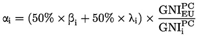

With

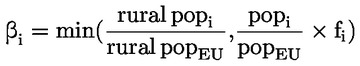

Where for each Member State i:

rural pop i is the population at risk of poverty living in rural areas of the Member State i;

rural pop EU is the sum of population at risk of poverty living in rural areas of the Member States of the EU-27;

pop i is the population of the Member State i;

pop EU is the sum of the population of the Member States of the EU-27;

HCO2 i is the carbon dioxide emissions from fuel combustion by households of the Member State i;

HCO2 EU is the sum of carbon dioxide emissions from fuel combustion by households of the Member States of the EU-27;

arrears i is the percentage of households at risk of poverty with arrears on utility bills of the Member State i;

arrears EU is the percentage of households at risk of poverty with arrears on utility bills of the EU-27;

For all Member States, α i cannot be lower than 0,07 % of the maximum amount as referred to in Article 10(1). The α i of all Member States with α i higher than 0,07 % are proportionally adjusted to ensure that the sum of all α i equals 100 %.

For the Member States with a GNI per capita below 90 % of the EU-27 value, α i cannot be lower than the share of reference emissions under Article 4(2) of Regulation (EU) 2018/842 for the emission sources 1A3b, 1A4a and 1A4b, as established in the 2006 IPCC Guidelines for National Greenhouse Gas Inventories for the average of the period 2016-2018, as comprehensively reviewed pursuant to Article 4(3) of that Regulation. The α i of the Member States with a GNI per capita above the EU-27 value are proportionally adjusted to ensure that the sum of all α i equals 100 %.

ANNEX II

Maximum financial allocation for each Member State under the Fund pursuant to Articles 10 and 14

The application of the methodology in Annex I to the amounts referred to in Article 10(1) results in the following share and maximum financial allocation for each Member State.

Any amounts pertaining from Article 10(3) will be covered within the limits of the maximum financial allocation for each Member State on a pro rata basis.

| Maximum financial allocation per Member State |  |  |  |
| --- | --- | --- | --- |
| Member State | Share as % of total | TOTAL 2026-2032 (in EUR, current prices) |  |
|  |  | Pursuant to Article 10(1), first and second subparagraphs | Pursuant to Article 10(1), third subparagraph |
| Belgium | 2,55 | 1 659 606 425 | 1 394 069 397 |
| Bulgaria | 3,85 | 2 499 490 282 | 2 099 571 836 |
| Czechia | 2,40 | 1 562 617 717 | 1 312 598 882 |
| Denmark | 0,50 | 324 991 338 | 272 992 724 |
| Germany | 8,18 | 5 317 778 511 | 4 466 933 949 |
| Estonia | 0,29 | 186 244 570 | 156 445 439 |
| Ireland | 1,02 | 663 390 868 | 557 248 329 |
| Greece | 5,52 | 3 586 843 608 | 3 012 948 631 |
| Spain | 10,52 | 6 837 784 631 | 5 743 739 090 |
| France | 11,19 | 7 276 283 944 | 6 112 078 513 |
| Croatia | 1,94 | 1 263 071 899 | 1 060 980 395 |
| Italy | 10,81 | 7 023 970 924 | 5 900 135 577 |
| Cyprus | 0,20 | 131 205 466 | 110 212 591 |
| Latvia | 0,71 | 463 676 528 | 389 488 284 |
| Lithuania | 1,02 | 664 171 367 | 557 903 948 |
| Luxembourg | 0,10 | 66 102 592 | 55 526 177 |
| Hungary | 4,33 | 2 815 968 174 | 2 365 413 267 |
| Malta | 0,07 | 45 500 000 | 38 220 000 |
| Netherlands | 1,11 | 720 463 632 | 605 189 451 |
| Austria | 0,89 | 578 936 189 | 486 306 399 |
| Poland | 17,60 | 11 439 026 446 | 9 608 782 215 |
| Portugal | 1,88 | 1 223 154 017 | 1 027 449 374 |
| Romania | 9,25 | 6 012 677 290 | 5 050 648 923 |
| Slovenia | 0,55 | 357 971 733 | 300 696 256 |
| Slovakia | 2,35 | 1 530 553 074 | 1 285 664 582 |
| Finland | 0,54 | 348 132 328 | 292 431 155 |
| Sweden | 0,62 | 400 386 447 | 336 324 616 |
| EU27 | 100 % | 65 000 000 000 | 54 600 000 000 |

ANNEX III

Key requirements for the Member State’s internal control system

1.

The Member State shall provide an effective and efficient internal control system, in accordance with its institutional, legal and financial framework, including separation of functions and reporting, supervising and monitoring arrangements.

This includes:

(a)

the designation of the authorities entrusted with the implementation of the Plan and the allocation of the related responsibilities and functions;

(b)

the designation of the authority or authorities responsible for signing the management declaration accompanying the payment requests;

(c)

procedures ensuring that this authority or these authorities will get assurance about the achievement of the milestones and targets set in the Plan, and that the funds were managed in accordance with all applicable rules, in particular rules on avoidance of conflicts of interests, fraud prevention, corruption and double funding;

(d)

an appropriate separation between managing and audit functions.

2.

The Member State shall conduct an effective implementation of proportionate anti-fraud and anti-corruption measures, as well as any necessary measure to effectively avoid conflict of interests.

This includes:

(a)

appropriate measures related to the prevention, detection and correction of fraud, corruption and conflict of interests, as well as avoidance of double funding and to take legal actions to recover funds that have been misappropriated;

(b)

a fraud risk assessment and the definition of appropriate anti-fraud mitigating measures.

3.

The Member State shall maintain appropriate procedures for drawing up the management declaration and summary of the audits carried out at national level.

This includes:

(a)

an effective procedure for drawing up the management declaration, documenting the summary of audits and keeping the underlying information for audit trail;

(b)

effective procedures to ensure that all cases of fraud, corruption and conflict of interests are properly reported and corrected through recoveries.

4.

To provide the information necessary, the Member State shall ensure appropriate management verifications, including procedures for checking the achievement of milestones and targets and compliance with horizontal principles of sound financial management.

This includes:

(a)

appropriate management verifications through which implementing authorities will check the achievement of milestones and targets of the fund (e.g. desk reviews, on-the-spot checks);

(b)

appropriate management verifications through which the implementing authorities will check the absence of serious irregularities, namely fraud, corruption and conflict of interests, and double funding (e.g. desk reviews, on-the-spot checks).

5.

The Member State shall conduct adequate and independent audits of systems and operations in accordance with internationally accepted audit standards.

This includes:

(a)

the designation of the body or bodies which will carry out the audits of systems and operations and how their functional independence is ensured;

(b)

the allocation of sufficient resources to this body or bodies for the purpose of the Fund;

(c)

the effective tackling by the body or bodies of the risk of fraud, corruption, conflict of interests and double funding both through system audits and audits of operations.

6.

The Member State shall maintain an effective system to ensure that all information and documents necessary for audit trail purposes are held.

This includes:

(a)

effective collection, recording and storage in an electronic system of data on the final recipients of measures or investments necessary to achieve the milestones and targets;

(b)

access for the Commission, OLAF, European Court of Auditors and in respect of those Member States participating in enhanced cooperation pursuant to Regulation (EU) 2017/1939, the EPPO, to the data on final recipients.

ANNEX IV

Common indicators for indicative milestones and targets for the Social Climate Plans of the Member States referred to in Article 6(1), point (m), monitoring by the Member State of the implementation of its Plan referred to in Article 24(1), evaluation by the Commission of the progress towards the objectives of the Fund referred to in Article 24(4)

Measures and investments can contribute to several of the common indicators. If a Member State’s Plan does not contain a measure or investment contributing to some of the indicators, a Member State may indicate ‘non-applicable’.

[output not shown]

(1) [OJ L 357, 27.10.2020, p. 35](http://publications.europa.eu/resource/oj/JOL_2020_357_R_TOC).

ANNEX V

Template for Social Climate Plans referred to in Article 6(7)

Table of Contents

| 1. | OVERVIEW AND PROCESS FOR ESTABLISHING THE SOCIAL CLIMATE PLAN | 43 |
| --- | --- | --- |

| 1.1. | Executive summary | 43 |
| --- | --- | --- |

| 1.2. | Overview of current policy situation | 43 |
| --- | --- | --- |

| 1.3. | Public consultation process | 43 |
| --- | --- | --- |

| 2. | DESCRIPTION OF THE MEASURES AND INVESTMENTS, MILESTONES AND TARGETS | 44 |
| --- | --- | --- |

| 2.1. | COMPONENT [1][2]: [buildings sector][transport sector] | 44 |
| --- | --- | --- |

| (i) | Description of the component | 44 |
| --- | --- | --- |

| (ii) | Description of the measures and investments of the component | 44 |
| --- | --- | --- |

| (iii) | Do no significant harm | 44 |
| --- | --- | --- |

| (iv) | Milestones, targets and timeline | 45 |
| --- | --- | --- |

| (v) | Financing and costs | 45 |
| --- | --- | --- |

| (vi) | Justification for benefitting entities other than vulnerable households, vulnerable micro-enterprises and vulnerable transport users (if applicable) | 45 |
| --- | --- | --- |

| (vii) | Estimated total costs of the component | 46 |
| --- | --- | --- |

| (viii) | Scenario in the event of a later start of the emissions trading system | 46 |
| --- | --- | --- |

| 2.2. | COMPONENT [3]: direct income support | 46 |
| --- | --- | --- |

| (i) | Description of the component | 46 |
| --- | --- | --- |

| (ii) | Description of the measures of the component | 46 |
| --- | --- | --- |

| (iii) | Milestones and targets for direct income support measures | 47 |
| --- | --- | --- |

| (iv) | Justification for the measures | 47 |
| --- | --- | --- |

| (v) | Costs of the measures | 47 |
| --- | --- | --- |

| (vi) | Justification for benefitting entities other than vulnerable households and vulnerable transport users (if applicable) | 47 |
| --- | --- | --- |

| (vii) | Estimated cost of the Plan for temporary direct income support component. | 48 |
| --- | --- | --- |

| (viii) | Scenario in the event of a later start of the emissions trading system | 48 |
| --- | --- | --- |

| 2.3. | Technical assistance | 48 |
| --- | --- | --- |

| 2.4. | Transfers to shared management programmes | 48 |
| --- | --- | --- |

| 2.5. | Estimated total costs of the Plan | 48 |
| --- | --- | --- |

| 3. | ANALYSIS AND OVERALL IMPACT | 49 |
| --- | --- | --- |

| 3.1. | Definitions | 49 |
| --- | --- | --- |

| 3.2. | Projected impact on vulnerable groups | 49 |
| --- | --- | --- |

| 3.3. | Projected impact of the planned measures and investments | 49 |
| --- | --- | --- |

| 4. | COMPLEMENTARITY, ADDITIONALITY AND IMPLEMENTATION OF THE PLAN | 50 |
| --- | --- | --- |

| 4.1. | Monitoring and implementation of the Plan | 50 |
| --- | --- | --- |

| 4.2. | Consistency with other initiatives | 50 |
| --- | --- | --- |

| 4.3. | Complementarity of funding | 50 |
| --- | --- | --- |

| 4.4. | Additionality | 50 |
| --- | --- | --- |

| 4.5. | Geographic specificities | 51 |
| --- | --- | --- |

| 4.6. | Prevention of corruption, fraud and conflicts of interests | 51 |
| --- | --- | --- |

| 4.7. | Information, communication and visibility | 51 |
| --- | --- | --- |

1. OVERVIEW AND PROCESS FOR ESTABLISHING THE SOCIAL CLIMATE PLAN

1.1. Executive summary

The context of the green transition in the Member State with particular emphasis on the main challenges from the social impacts of the inclusion of greenhouse gas emissions from buildings and road transport sectors within the scope of Directive 2003/87/EC and how the Plan will respond to these challenges.

An overview table that sums up the main objectives of the Plan, together with the estimated total costs of the Plan, including the contribution from the Fund, the national contribution and resources from shared management programs to be transferred to the Fund, divided into the three areas of intervention: measures and investments for the buildings sector, for the road transport sector, and measures for direct income support, based on the template below:

| Area of intervention | Total costs (absolute and % of total funding) by source of funding | Overview of main measures and investments planned | Objectives of the measures and investments | Impact of measures and investments |  |
| --- | --- | --- | --- | --- | --- |
|  |  |  |  | Reduction of vulnerable households and vulnerable transport users (unit: households) | CO2 emissions reduction |
| Buildings sector |  |  |  |  |  |
| Road Transport sector |  |  |  |  |  |
| Temporary direct income support |  |  |  |  |  |
| Technical assistance (Article 8(3)) |  |  |  |  |  |
| Contribution to the Technical Support Instrument (Article 11(3)) |  |  |  |  |  |
| Contribution to the Member State’s compartment in InvestEU (Article 11(3)) |  |  |  |  |  |

1.2. Overview of current policy situation

Information on the current national energy and climate policies, how they are being applied in the national context, with a particular focus on buildings and transport sectors and in respect to the most vulnerable groups.

1.3. Public consultation process

A summary of the consultation process of local and regional authorities, social partners, civil society organisations, youth organisations, and other relevant stakeholders, as implemented in accordance with the national legal framework, for the preparation and, where available implementation of the Plan, covering the scope, type, and timing of consultations activities, as well as how the views of the stakeholders are reflected in the Plan.

2. DESCRIPTION OF THE MEASURES AND INVESTMENTS, MILESTONES AND TARGETS

Information for each component for the three areas of the Plan separately:

| — | buildings sector; |
| --- | --- |

| — | road transport sector; |
| --- | --- |

| — | temporary direct income support. |
| --- | --- |

A component may include several sub-components focusing on a specific challenge or need. Each component or sub-component may include one or several closely linked or mutually dependent measures or investments.

2.1. COMPONENT [1][2]: [buildings sector][transport sector]

Information on the component:

(i) Description of the component

Summary box:

Summary box for Component [1][2] [buildings sector][transport sector]

Intervention area: [buildings sector][transport sector]

Objective:

Measures and investments:

Estimated total costs: EUR xx, of which

Costs requested to be covered under the Fund: EUR xx

Costs to be covered by the national contribution: EUR xx

(ii) Description of the measures and investments of the component

Detailed description of the component and its specific measures and investments, as well as their interlinkages and synergies, covering the following:

| — | Clear and evidence-based analysis of the existing challenges and how they are addressed by the measures and the investments; |
| --- | --- |

—

The nature, type and size of the measure or investment, which may include additional technical support measures in accordance with Article 11(4), indicating whether it is new or is an existing measure or investment intended to be extended with the support from the Fund;

—

Detailed information on the objective of the measure or investment and about who and what is targeted by it; an explanation of how the measure and investment would contribute effectively to the achievement of the objectives of the Fund within the overall setting of a Member State’s relevant policies, and how it will reduce fossil fuel dependency;

—

Description of how the measure or investment is implemented (means of implementation), referring to the administrative capacity of the Member State at central, and where relevant regional and local levels, with an explanation on how the resources will be absorbed in a timely manner and how they are channelled to sub-national levels, if applicable;

| — | An explanation of how the measure or investment will aim to address gender inequality, if applicable; |
| --- | --- |

| — | The timeline of the measure or investment; for support concerning low-emission vehicles, a timetable for gradually reducing that support. |
| --- | --- |

(iii) Do no significant harm

Information on how measures and investments included in the component comply with the principle of ‘do no significant harm’ within the meaning of Article 17 of Regulation (EU) 2020/852. The Commission will provide technical guidance, pursuant to Article 6(5) of this Regulation.

(iv) Milestones, targets and timeline

Information on each milestone and target that will reflect the progress on implementing measures and investments of this component, as follows:

| — | why the specific milestone or target was chosen; |
| --- | --- |

| — | what the milestone or target is measuring; |
| --- | --- |

—

how this will be measured, what methodology and source will be used, and how the proper achievement of the milestone or target will be objectively verified;

| — | what is the baseline (starting point) and what is the level or specific point to be reached; |
| --- | --- |

| — | by when it will be reached (by quarter and year); |
| --- | --- |

| — | who and which institution will be in charge of implementing, measuring and reporting. |
| --- | --- |

Table containing milestones, targets and timeline for the components with the following information:

| Seq. number | Measure/Investment name | Milestone or Target | Name of milestone/target | Qualitative indicators (milestones) | Quantitative indicators (targets) |  |  | Timeline for achievement |  | Description of each milestone and target |
| --- | --- | --- | --- | --- | --- | --- | --- | --- | --- | --- |
|  |  |  |  |  | Unit of measure/investment | Baseline | Goal | Quarter | Year |  |

(v) Financing and costs

Information and explanation on the estimated total costs of the component and for each measure and investment, backed up by appropriate justification, including:

| — | The methodology used, the underlying assumptions made (e.g. on unit costs, costs of inputs) and justification for these assumptions; |
| --- | --- |

| — | The indicative comprehensive timetable within which these costs are expected to be incurred; |
| --- | --- |

| — | Information on the national contribution to the total costs of the measures and investments; |
| --- | --- |

| — | Any information on what financing from other Union instruments is or could be envisaged related to the same component; |
| --- | --- |

| — | Any information on envisaged financing from private sources and which leverage level is targeted, if relevant; |
| --- | --- |

| — | Justification on the plausibility and reasonability of the estimated costs, where necessary, taking into account national specificities. |
| --- | --- |

(vi) Justification for benefitting entities other than vulnerable households, vulnerable micro-enterprises and vulnerable transport users (if applicable)

If support from the Fund is provided through public or private entities other than vulnerable households, vulnerable micro-enterprises, or vulnerable transport users, an explanation of what measures or investments those entities will enact and how those measures and investments will ultimately be to the benefit of vulnerable households, vulnerable micro-enterprises and vulnerable transport users;

If support from the Fund is provided through financial intermediaries, a description of the measures that the Member State intends to adopt to ensure that financial intermediaries pass on the entire benefit to the final recipients.

(vii) Estimated total costs of the component

Completion of the table on the estimated cost of measures and investments included in the component, in accordance with the template provided below:

| Seq. number | Related measure (measure or investment) | Relevant time period |  | Estimated costs for which funding from the Fund is requested |  |  |  |  |  |  |  |
| --- | --- | --- | --- | --- | --- | --- | --- | --- | --- | --- | --- |
|  |  |  |  | Total requested | If available: split by year |  |  |  |  |  |  |
|  |  | From date | To date | Amount (mn EUR) | 2026 | 2027 | 2028 | 2029 | 2030 | 2031 | 2032 |

(viii) Scenario in the event of a later start of the emissions trading system

A description and quantification of the necessary adjustments to the measures, investments, milestones, targets, the amount of national contribution and any other relevant element of the Plan resulting from the postponement of the start of the emissions trading system established pursuant to Chapter IVa of Directive 2003/87/EC in accordance with Article 30k of that Directive.

A separate version of the summary box, the table on milestones, targets and timeline and the table on estimated costs.

2.2. COMPONENT [3]: direct income support

Information on the Component for the direct income support:

(i) Description of the component

Summary box:

Summary box for Component 3 – direct income support

Intervention area: direct income support

Objective:

Measures:

Estimated total costs: EUR xx, of which

Costs requested to be covered under the Fund: EUR xx

Costs to be covered by the national contribution: EUR xx

(ii) Description of the measures of the component

A detailed description of the component and its specific measures, as well as their interlinkages and synergies, including:

| — | Clear and evidence-based analysis of the existing challenges and how they are addressed and the objectives of the support; |
| --- | --- |

| — | The nature, type and size of the support; |
| --- | --- |

| — | Detailed information on the final recipients of the support and the criteria used for their identification; |
| --- | --- |

| — | The timeline for the decrease in direct income support in line with the timeline of the Fund, including a concrete end date for the support; |
| --- | --- |

| — | An explanation of how the support will aim to address gender inequality, if applicable; |
| --- | --- |

| — | Description of how the support is implemented; |
| --- | --- |

| — | Information on the national contribution to the costs of the measures. |
| --- | --- |

(iii) Milestones and targets for direct income support measures

Information on each milestone and target that will reflect the progress on implementing of this component, as follows:

| — | why the specific milestone or target was chosen; |
| --- | --- |

| — | what the milestone or target is measuring; |
| --- | --- |

—

how this will be measured, what methodology and source will be used, and how the proper achievement of the milestone or target will be objectively verified;

| — | what is the baseline (starting point) and what is the level or specific point to be reached; |
| --- | --- |

| — | by when it will be reached; |
| --- | --- |

| — | who and which institution will be in charge of implementing, measuring and reporting. |
| --- | --- |

Table containing milestones, targets and timeline for temporary direct income support measures, template provided below:

| Seq. number | Measure | Milestone or Target | Name of milestone/target | Qualitative indicators (milestones) | Quantitative indicators (targets) |  |  | Timeline for achievement |  | Description of each milestone and target |
| --- | --- | --- | --- | --- | --- | --- | --- | --- | --- | --- |
|  |  |  |  |  | Unit of measure | Baseline | Goal | Quarter | Year |  |

(iv) Justification for the measures

Justification for the need of temporary direct income support based on the criteria laid out in Articles 6(1) and 8(2):

—

Quantitative estimate and a qualitative explanation of how the measures in the Plan are expected to reduce energy poverty and transport poverty and the vulnerability of households and transport users to an increase of road transport and heating fuel prices;

| — | Justification on the proposed timeline of the diminishing temporary direct income support and the conditions when it no longer applies; |
| --- | --- |

—

Description of how the groups of recipients of temporary direct income support are also targeted by structural measures and investments to effectively lift them out of energy poverty and transport poverty, and description of the complementarity of temporary direct income support with structural measures and investments to support vulnerable households and vulnerable transport users.

(v) Costs of the measures

Information on the estimated total costs of the component, backed up by appropriate justification, including:

| — | The methodology used, the underlying assumptions made and justification for these assumptions; |
| --- | --- |

| — | The comparative cost data on the actual cost, if similar support measures have been carried out in the past; |
| --- | --- |

| — | Any information on what financing from other Union instruments is or could be foreseen related to the same support; |
| --- | --- |

—

Appropriate detailed justification on the plausibility and reasonability of the estimated costs, including any data or evidence used annexed to the Plan.

(vi) Justification for benefitting entities other than vulnerable households and vulnerable transport users (if applicable)

If the support from the Fund is provided through public or private entities other than vulnerable households, or vulnerable transport users, an explanation what kind of measures those entities will enact and how those measures will ultimately be to the benefit of vulnerable households, or vulnerable transport users.

If support from the Fund is provided through financial intermediaries, a description of the measures that the Member State intends to adopt to ensure that financial intermediaries pass on the entire benefit to the final recipients.

(vii) Estimated cost of the Plan for temporary direct income support component.

Completion of the table on estimated cost of support included in the component, template provided below:

| Seq. number | Type of support | Relevant time period |  | Estimated costs for which funding from the Fund is requested |  |  |  |  |  |  |  |
| --- | --- | --- | --- | --- | --- | --- | --- | --- | --- | --- | --- |
|  |  |  |  | Total requested | If available: split by year |  |  |  |  |  |  |
|  |  | From date | To date | Amount (mn EUR) | 2026 | 2027 | 2028 | 2029 | 2030 | 2031 | 2032 |

(viii) Scenario in the event of a later start of the emissions trading system

A description and quantification of the necessary adjustments to the measures, investments, milestones, targets, the amount of national contribution and any other relevant element of the Plan resulting from the postponement of the start of the emissions trading system established pursuant to Chapter IVa of Directive 2003/87/EC in accordance with Article 30k of that Directive.

A separate version of the summary box, the table on milestones, targets and timeline and the table on estimated costs.

2.3. Technical assistance

A description of the technical assistance actions that will be included for the effective administration and implementation of the measures and investments set out in the Plan, in accordance with Article 8(3), including:

| — | the nature, type and size of the technical assistance actions; |
| --- | --- |

| — | the estimated cost of the technical assistance actions. |
| --- | --- |

2.4. Transfers to shared management programmes

If resources are intended to be transferred from the Fund to funds under shared management pursuant to Article 11(2), indication of which programmes these resources will be transferred to and under which timeline, and indication of how the measures and investments to be implemented under those programmes would comply with the objectives referred to in Article 3, including whether they fall under the measures and investments set out in Article 8.

2.5. Estimated total costs of the Plan

Estimated total costs of the Plan, including any amounts made available for additional technical support under Article 11(4) of this Regulation, the amount of the cash contribution for the purpose of the Member State compartment pursuant to the relevant provisions of Regulation (EU) 2021/523 and any amount made available for additional technical assistance under Article 8(3) of this Regulation.

An indication of the national contribution to the total costs of its plan, including an indication of any resources intended to be transferred to the Fund from shared management programmes pursuant to Article 11(1) of this Regulation and any resources intended to be transferred from the Fund to shared management programmes pursuant to Article 11(2) of this Regulation.

A description of how the costs are in line with the principle of cost efficiency and commensurate to the expected impact of the Plan.

Completion of the table summarising the cost of the Fund by source of funding, template provided below:

| Total costs of Social Climate Plan | Base case | In case of Article 30k Directive 2003/87/EC |
| --- | --- | --- |
| ESTIMATED TOTAL COSTS OF THE PLAN, of which | EUR XXX | EUR XXX |
| Covered under the Fund | EUR XXX | EUR XXX |
| National contribution | EUR XXX | EUR XXX |
| Transfers from shared management programmes | EUR XXX | EUR XXX |
| (Transfers to shared management programmes) | -EUR XXX | -EUR XXX |

3. ANALYSIS AND OVERALL IMPACT

3.1. Definitions

An explanation of how the definitions of energy poverty and transport poverty are to be applied at national level.

3.2. Projected impact on vulnerable groups

An estimate of the likely effects of the increase in prices resulting from the emissions trading system established pursuant to Chapter IVa of Directive 2003/87/EC on households, and in particular on incidence of energy poverty and transport poverty, and on micro-enterprises, comprising in particular an estimated number of, and the identification of, vulnerable households, vulnerable micro-enterprises and vulnerable transport users. These effects are to be analysed at the appropriate territorial level as established by each Member State, taking into account national specificities and elements such as access to public transport and basic services and identifying the areas mostly affected.

A description of the methodology used in the estimates, while making sure that the estimates are calculated with a sufficient level of regional disaggregation.

3.3. Projected impact of the planned measures and investments

An estimate of the projected impacts of the measures and investments planned in section 2 on greenhouse gas emissions, energy poverty and transport poverty, with comparison to the baseline described above.

A description of the methodology used in the estimates.

Qualitative and quantitative tables on the impact of the Plan, template provided below:

| Component | Description of the expected impacts of the component on: (mark include relevant quantitative indicators) |  |  |  |  |
| --- | --- | --- | --- | --- | --- |
|  | Energy efficiency | Building renovation | Zero- and low-emission mobility and transport | Greenhouse gas emission reductions | Reduction in the number of vulnerable households and vulnerable transport users (unit: households) |
| Overall plan |  |  |  |  |  |
| Buildings sector |  |  |  |  |  |
| Road transport sector |  |  |  |  |  |

| Component | Quantification of the impact (if available) i.e. % difference from policy neutral baseline |  |  |  |  |  |
| --- | --- | --- | --- | --- | --- | --- |
|  | Short-term (3 years ahead) |  |  | Medium-term (end of the plan) |  |  |
|  | Greenhouse gas emissions | Households in energy poverty | Households in transport poverty | Greenhouse gas emissions | Households in energy poverty | Households in transport poverty |
| Overall plan |  |  |  |  |  |  |
| Buildings sector |  |  |  |  |  |  |
| Road transport sector |  |  |  |  |  |  |

Qualitative and quantitative table on the expected impact of the temporary direct income support measures on the reduction of the number of vulnerable households and vulnerable transport users as well as households in energy poverty and in transport poverty, template provided below:

| Component: direct income support |  |
| --- | --- |
| Reduction in the number of vulnerable households and vulnerable transport users | Description of the expected impacts |
|  | Estimate of expected impacts; unit: households |
| Reduction in the number of households in energy poverty and in transport poverty | Description of the expected impacts |
|  | Estimate of expected impacts; unit: households |

4. COMPLEMENTARITY, ADDITIONALITY AND IMPLEMENTATION OF THE PLAN

This part concerns the whole Plan. The various criteria set out below need to be justified for the Plan as a whole.

4.1. Monitoring and implementation of the Plan

Explanation on how the Member State intends to implement the proposed measures and investments, focusing on the arrangements and timetable for monitoring and implementation including, where relevant, measures necessary for compliance with Article 21.

4.2. Consistency with other initiatives

Explanation on how the Plan is consistent with the information included and the commitments made by the Member State under other relevant plans and funds, and the interplay among the different plans going forward, as set out in Article 6(3) and Article 16(3), point (b)(iii).

4.3. Complementarity of funding

Information on existing or planned financing of measures and investments from other Union, international, public or, where relevant, private sources which contribute to the measures and investments set out in the Plan, including on temporary direct income support, pursuant to Article 6(1), point (c).

4.4. Additionality

Explanation and justification of how the new or existing measures or investments are additional and do not substitute recurring national budgetary expenditure, pursuant to Article 13(2), including such explanation and justification with regard to measures and investments included in the Plan in accordance with Article 4(5).

4.5. Geographic specificities

Explanation of how geographic specificities, such as islands, outermost regions and territories, rural or remote areas, less accessible peripheries, mountainous areas or areas lagging behind, have been taken into account by the Plan.

4.6. Prevention of corruption, fraud and conflicts of interests

A system to prevent, detect and correct corruption, fraud and conflicts of interests, when using the funds provided under the Fund, and the arrangements that aim to avoid double funding from the Fund and other Union programmes in accordance with Article 21 and Annex III, including funds provided through public or private entities other than vulnerable households, vulnerable micro-enterprises and vulnerable transport users in accordance with Article 9.

4.7. Information, communication and visibility

Compliance with the provisions set out in Article 23 referring to public access to data, indicating the website in which the data will be published, as well as the information, communication, and visibility measures.

Outline of the intended national communication strategy aimed at ensuring public awareness of the Union funding.